# Prediction of Student Performance in Secondary Education

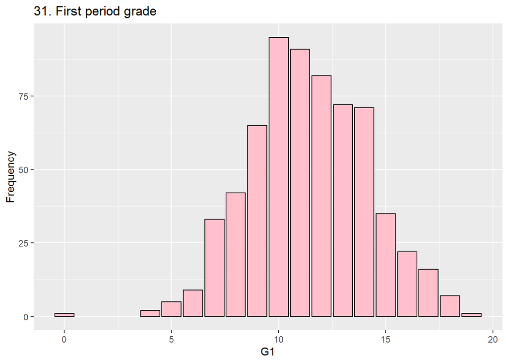

```r
ggplot(df, aes(x = G1)) +
  geom_bar(
    fill = "pink",
    color = "black"
  ) +
  labs(
    x = "G1",
    y = "Frequency",
    title = "31. First period grade"
  )
```

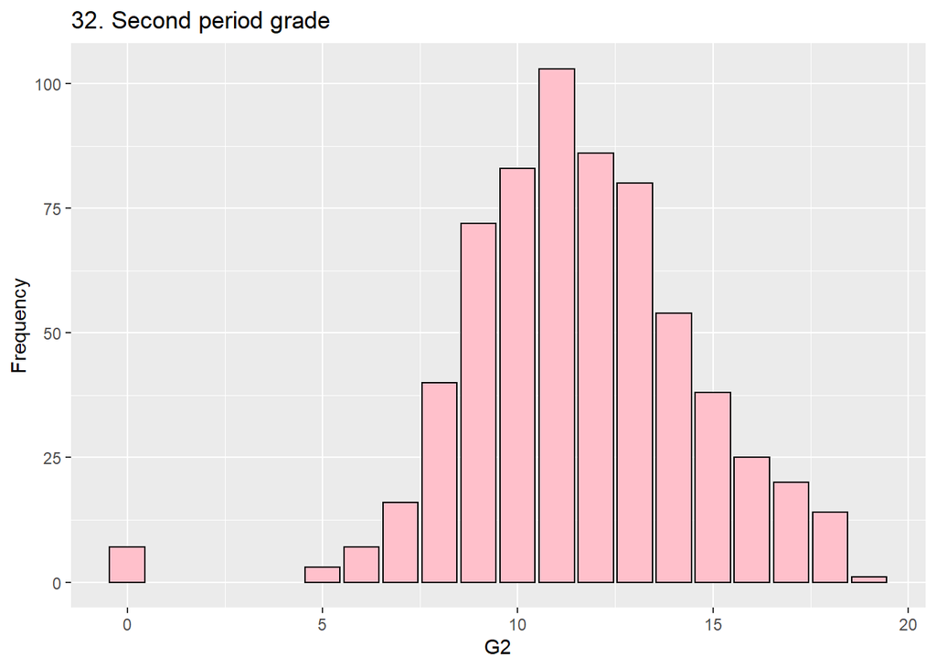

```r
ggplot(df, aes(x = G2)) +
  geom_bar(
    fill = "pink",
    color = "black"
  ) +
  labs(
    x = "G2",
    y = "Frequency",
    title = "32. Second period grade"
  )
```

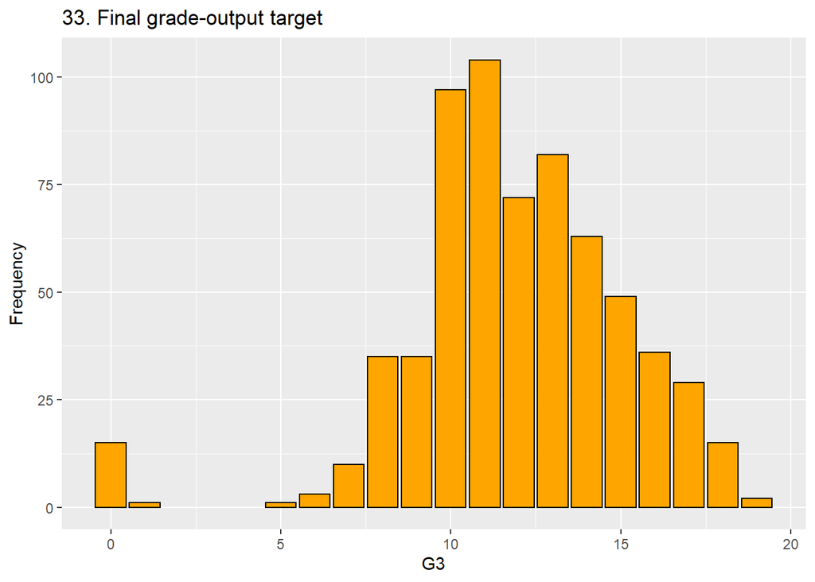

```r
ggplot(df, aes(x = G3)) +
  geom_bar(
    fill = "orange",
    color = "black"
  ) +
  labs(
    x = "G3",
    y = "Frequency",
    title = "33. Final grade-output target"
  )
```

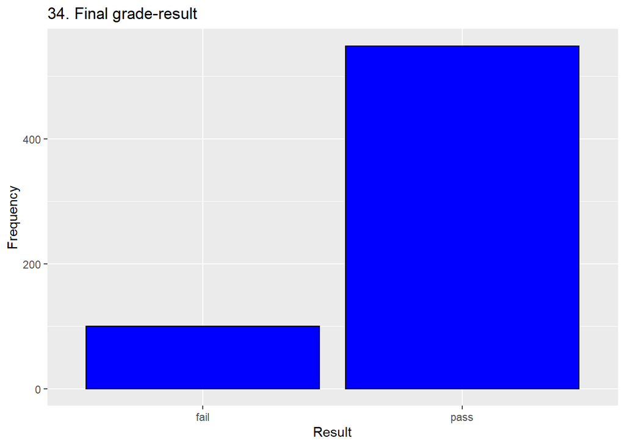

```r
ggplot(df, aes(x = result)) +
  geom_bar(
    fill = "blue",
    color = "black"
  ) +
  labs(
    x = "Result",
    y = "Frequency",
    title = "34. Final grade-result"
  )
```

#### Bivariate

General Function for Bar Graph Plotting

```r
# bar graph for bivariate analysis
Unstacked_bi_bar_graph <- function(`x.axis` = "", Result = "") {
  # Result represents dependent variable / usually being drawn in y-axis
  # x-axis represent independent variable
  # dodge is used to un-stake the bar graph

  # 1. counts (or sums of weights)
  bar <- ggplot(df, aes(`x.axis`))

  # 2. Number of tuples in each class
  graph_output <- bar + geom_bar(aes(fill = `Result`), position = "dodge") +
    labs(y = "Frequency")

  # 3. get data from the graph
  graph_label <- layer_data(graph_output)

  # 4. Annotate value at respective bar
  graph_output <- graph_output + annotate(
    geom = "text", label = graph_label$count,
    x = graph_label$x, y = 15
  )

  return(graph_output)
}
```

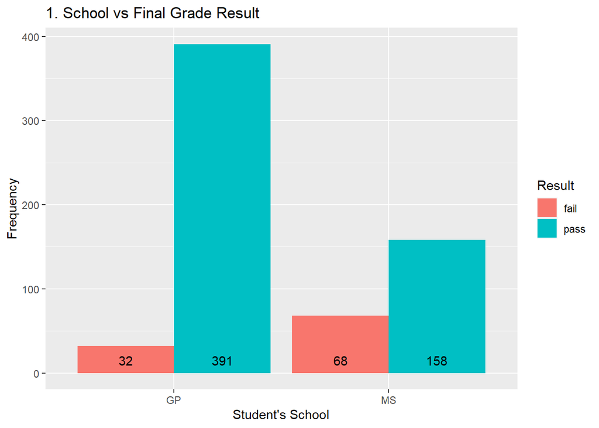

```r
bar.bivar <- Unstacked_bi_bar_graph(df$school, df$result)
bar.bivar <- bar.bivar + ggtitle(label = "1. School vs Final Grade Result") +
  labs(x = "Student's School")
bar.bivar
```

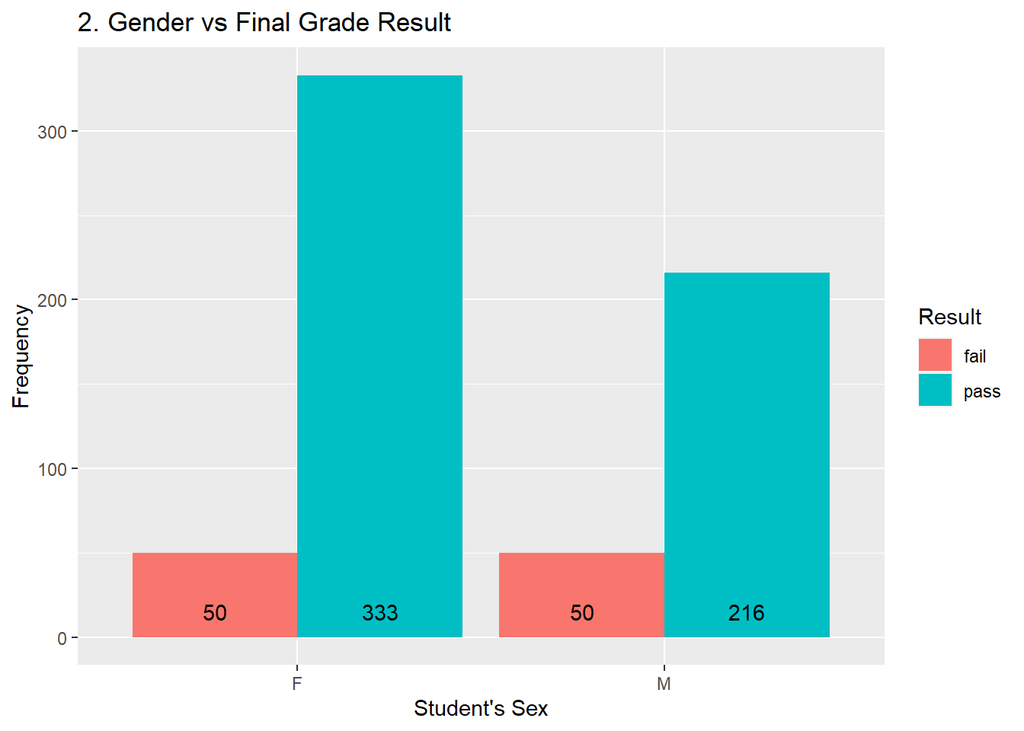

```r
bar.bivar <- Unstacked_bi_bar_graph(df$sex, df$result)
bar.bivar <- bar.bivar + ggtitle(label = "2. Gender vs Final Grade Result") +
  labs(x = "Student's Sex")
bar.bivar
```

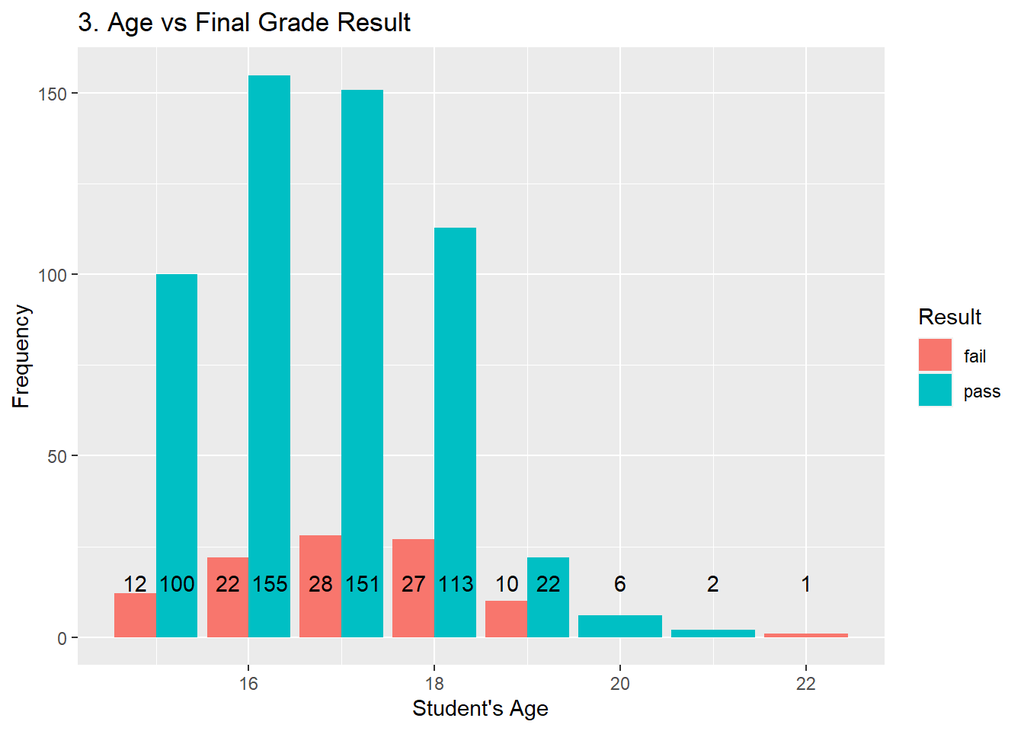

```r
bar.bivar <- Unstacked_bi_bar_graph(df$age, df$result)
bar.bivar <- bar.bivar + ggtitle(label = "3. Age vs Final Grade Result") +
  labs(x = "Student's Age")
bar.bivar
```

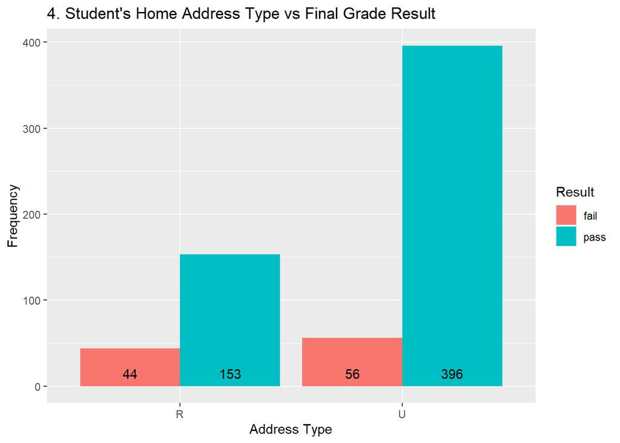

```r
bar.bivar <- Unstacked_bi_bar_graph(df$address, df$result)
bar.bivar <- bar.bivar + ggtitle(label = "4. Student's Home Address Type vs Final Grade Result") +
  labs(x = "Address Type")
bar.bivar
```

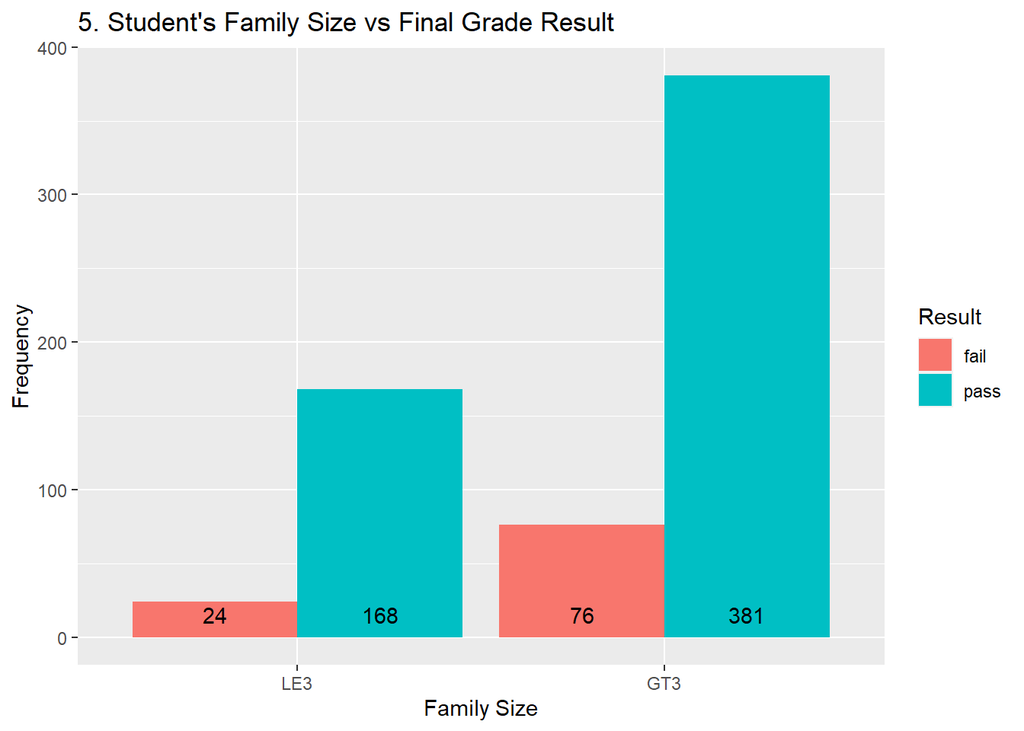

```r
bar.bivar <- Unstacked_bi_bar_graph(df$famsize, df$result)
bar.bivar <- bar.bivar + ggtitle(label = "5. Student's Family Size vs Final Grade Result") +
  labs(x = "Family Size")
bar.bivar
```

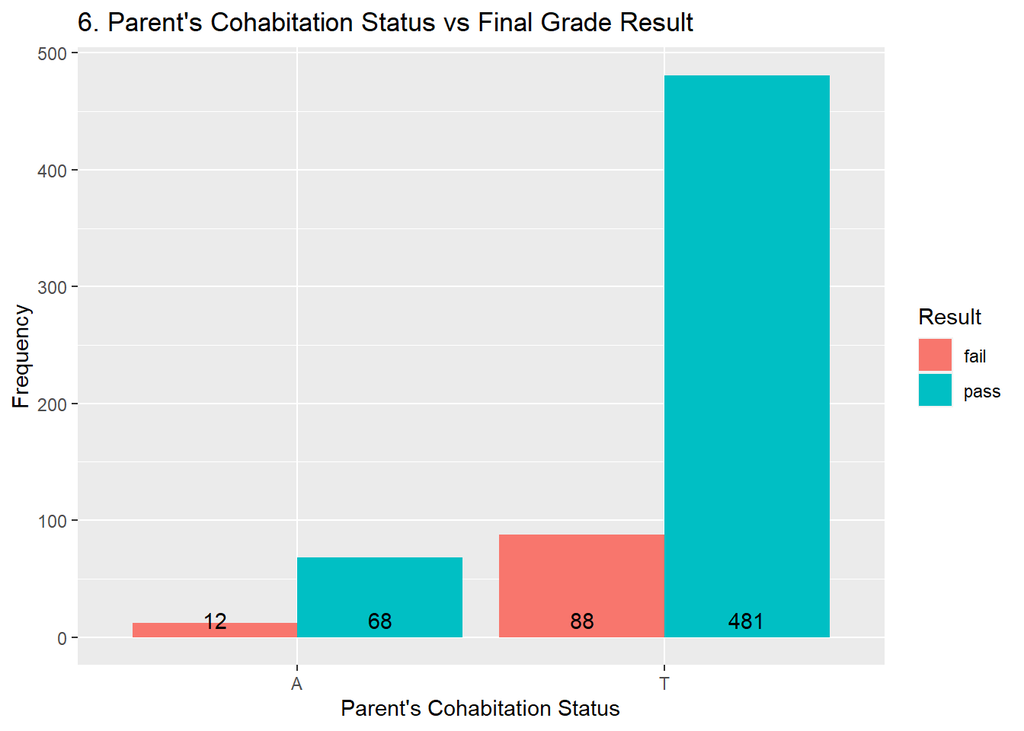

```r
bar.bivar <- Unstacked_bi_bar_graph(df$Pstatus, df$result)
bar.bivar <- bar.bivar + ggtitle(label = "6. Parent's Cohabitation Status vs Final Grade Result") +
  labs(x = "Parent's Cohabitation Status")
bar.bivar
```

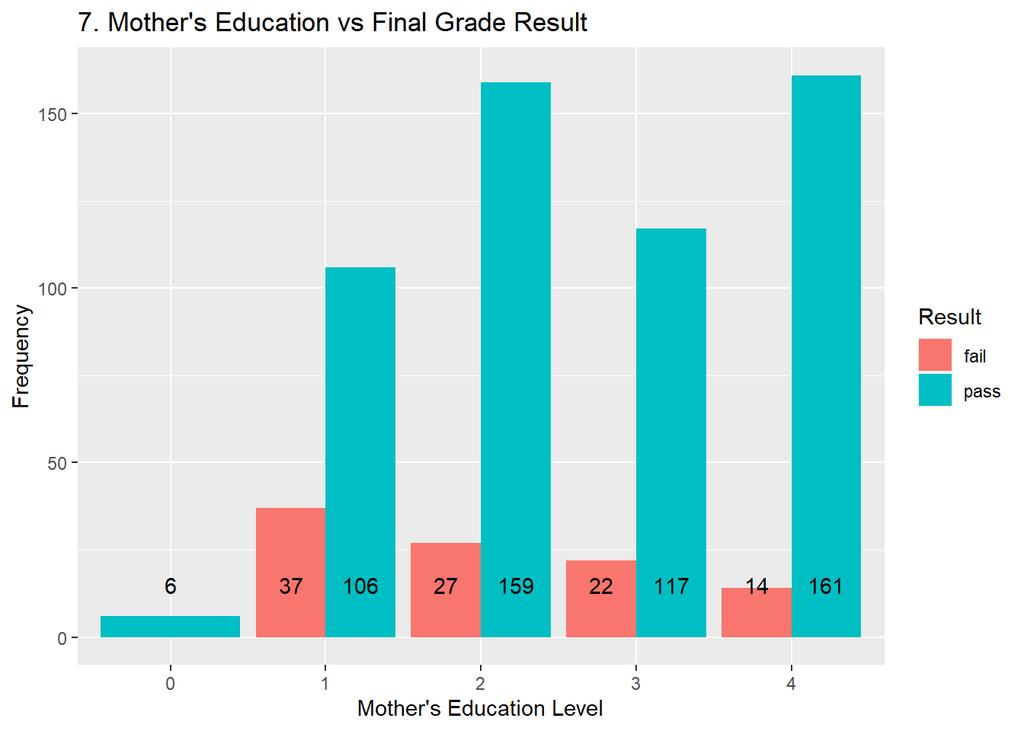

```r
bar.bivar <- Unstacked_bi_bar_graph(df$Medu, df$result)
bar.bivar <- bar.bivar + ggtitle(label = "7. Mother's Education vs Final Grade Result") +
  labs(x = "Mother's Education Level")
bar.bivar
```

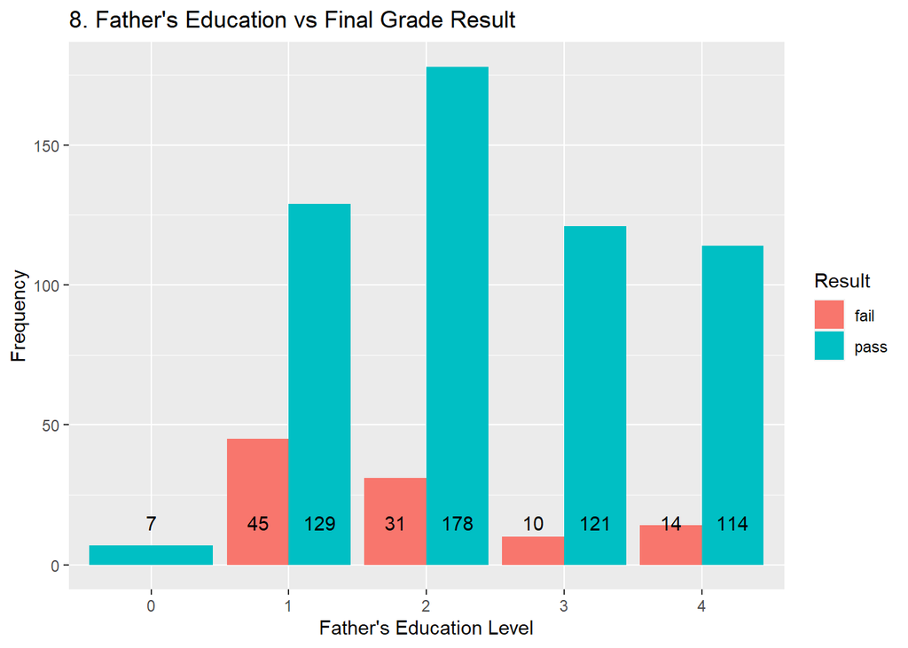

```r
bar.bivar <- Unstacked_bi_bar_graph(df$Fedu, df$result)
bar.bivar <- bar.bivar + ggtitle(label = "8. Father's Education vs Final Grade Result") +
  labs(x = "Father's Education Level")
bar.bivar
```

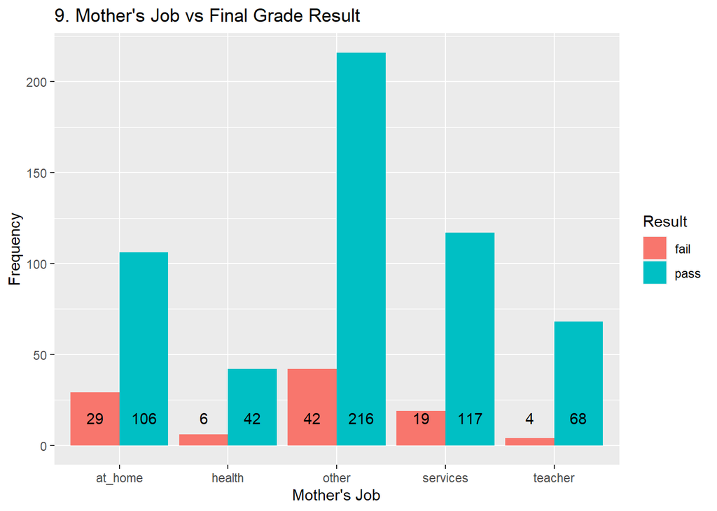

```r
bar.bivar <- Unstacked_bi_bar_graph(df$Mjob, df$result)
bar.bivar <- bar.bivar + ggtitle(label = "9. Mother's Job vs Final Grade Result") +
  labs(x = "Mother's Job")
bar.bivar
```

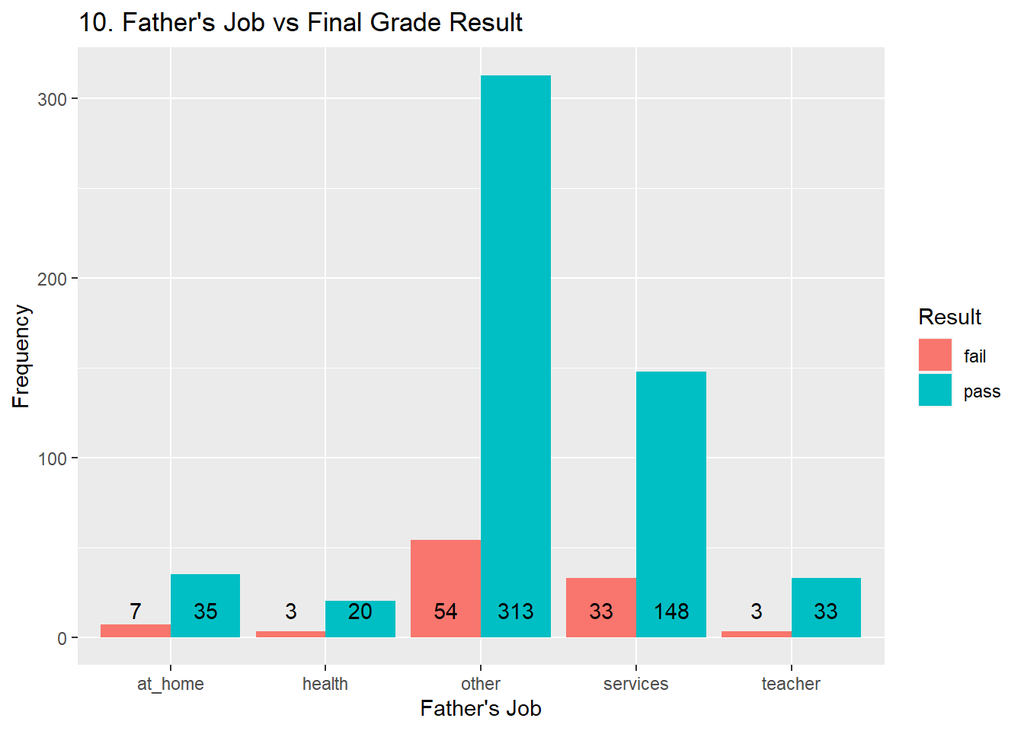

```r
bar.bivar <- Unstacked_bi_bar_graph(df$Fjob, df$result)
bar.bivar <- bar.bivar + ggtitle(label = "10. Father's Job vs Final Grade Result") +
  labs(x = "Father's Job")
bar.bivar
```

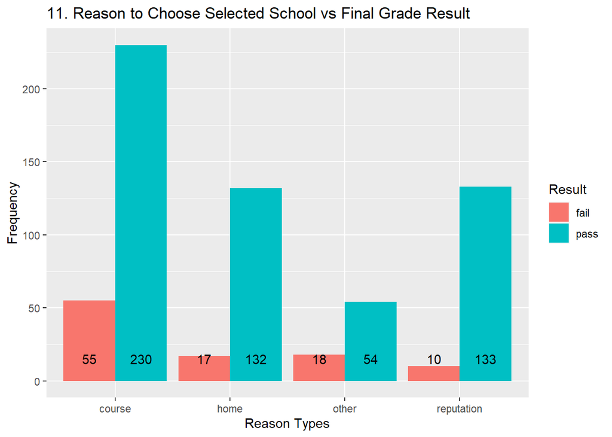

```r
bar.bivar <- Unstacked_bi_bar_graph(df$reason, df$result)
bar.bivar <- bar.bivar + ggtitle(label = "11. Reason to Choose Selected School vs Final Grade Result") + labs(x = "Reason Types")
bar.bivar
```

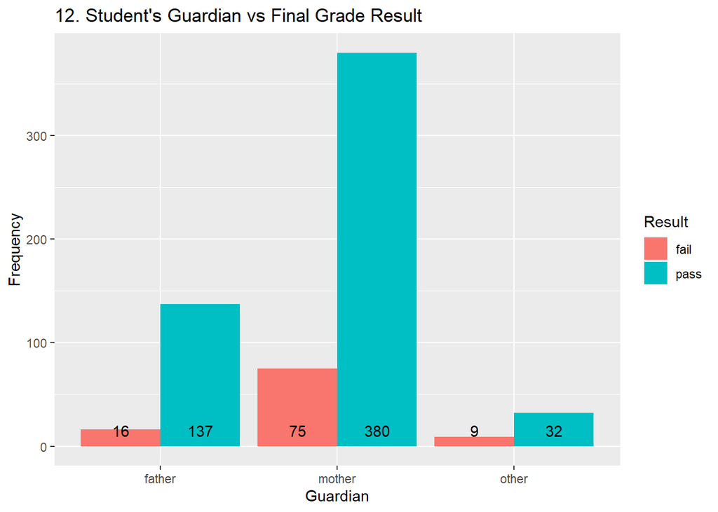

```r
bar.bivar <- Unstacked_bi_bar_graph(df$guardian, df$result)
bar.bivar <- bar.bivar + ggtitle(label = "12. Student's Guardian vs Final Grade Result") +
  labs(x = "Guardian")
bar.bivar
```

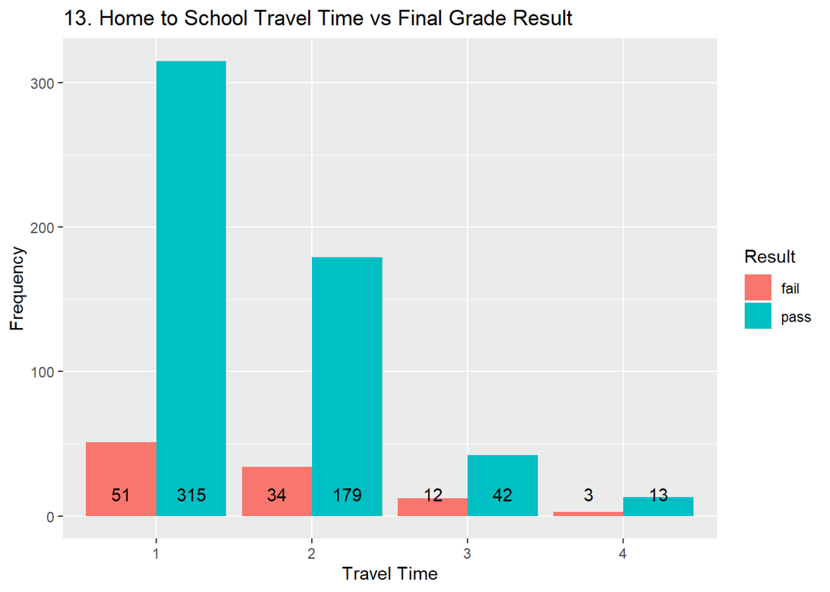

```r
bar.bivar <- Unstacked_bi_bar_graph(df$traveltime, df$result)
bar.bivar <- bar.bivar + ggtitle(label = "13. Home to School Travel Time vs Final Grade Result") +
  labs(x = "Travel Time")
bar.bivar
```

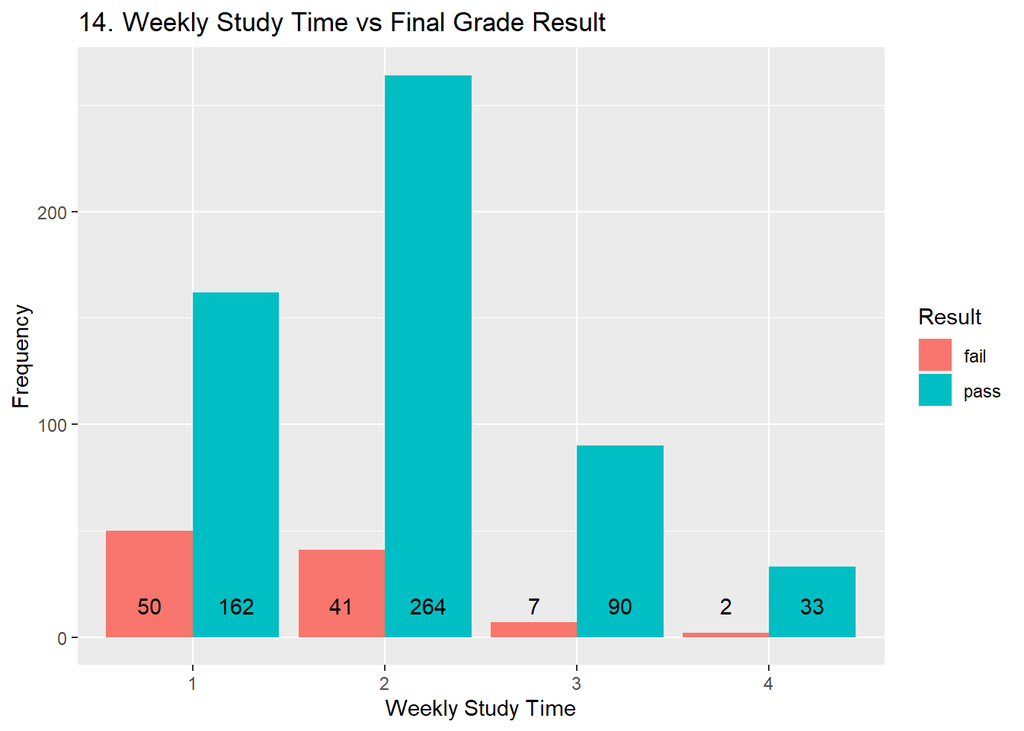

```r
bar.bivar <- Unstacked_bi_bar_graph(df$studytime, df$result)
bar.bivar <- bar.bivar + ggtitle(label = "14. Weekly Study Time vs Final Grade Result") +
  labs(x = "Weekly Study Time")
bar.bivar
```

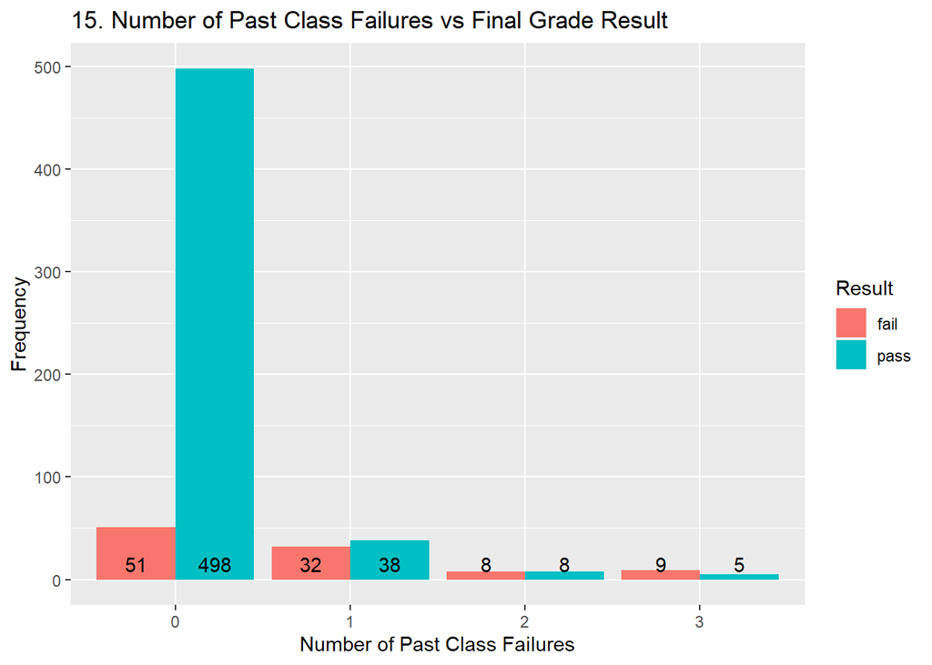

```r
bar.bivar <- Unstacked_bi_bar_graph(df$failures, df$result)
bar.bivar <- bar.bivar + ggtitle(label = "15. Number of Past Class Failures vs Final Grade Result") +
  labs(x = "Number of Past Class Failures")
bar.bivar
```

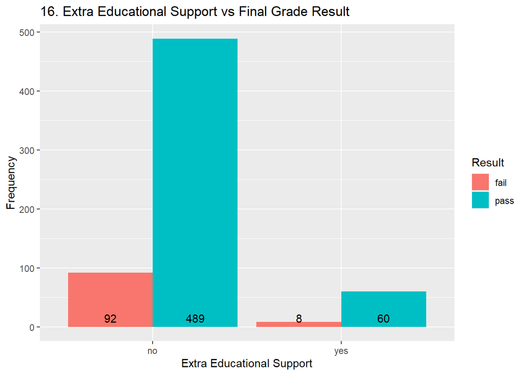

```r
bar.bivar <- Unstacked_bi_bar_graph(df$schoolsup, df$result)
bar.bivar <- bar.bivar + ggtitle(label = "16. Extra Educational Support vs Final Grade Result") +
  labs(x = "Extra Educational Support")
bar.bivar
```

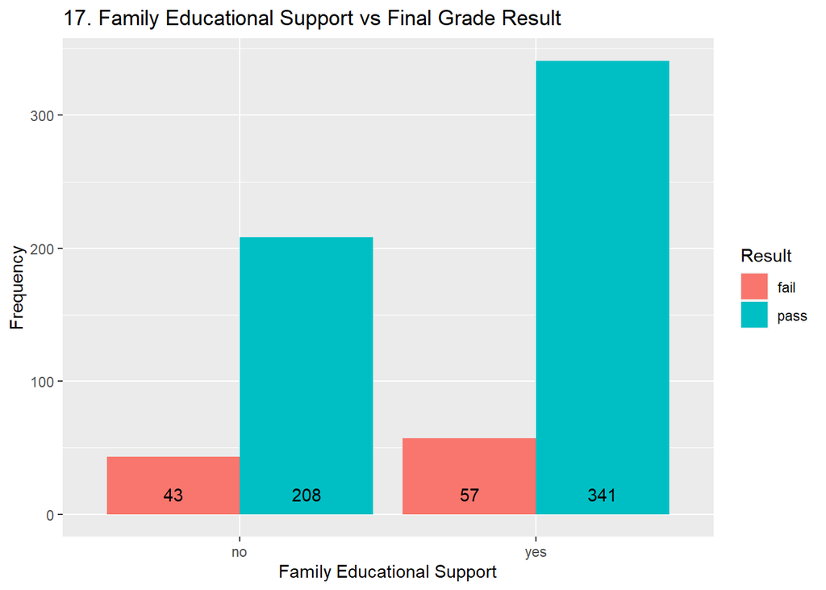

```r
bar.bivar <- Unstacked_bi_bar_graph(df$famsup, df$result)
bar.bivar <- bar.bivar + ggtitle(label = "17. Family Educational Support vs Final Grade Result") +
  labs(x = "Family Educational Support")
bar.bivar
```

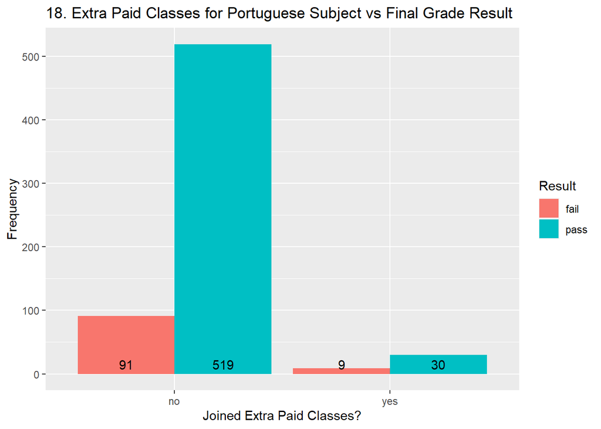

```r
bar.bivar <- Unstacked_bi_bar_graph(df$paid, df$result)
bar.bivar <- bar.bivar +
  ggtitle(label = "18. Extra Paid Classes for Portuguese Subject vs Final Grade Result") +
  labs(x = "Joined Extra Paid Classes?")
bar.bivar
```

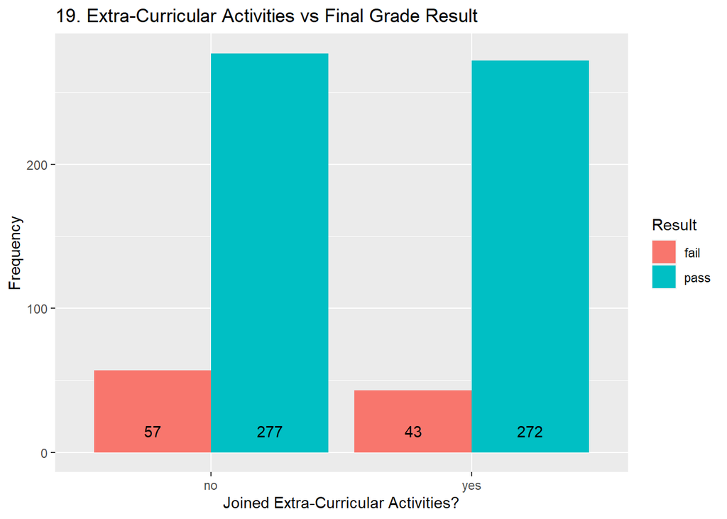

```r
bar.bivar <- Unstacked_bi_bar_graph(df$activities, df$result)
bar.bivar <- bar.bivar + ggtitle(label = "19. Extra-Curricular Activities vs Final Grade Result") +
  labs(x = "Joined Extra-Curricular Activities?")
bar.bivar
```

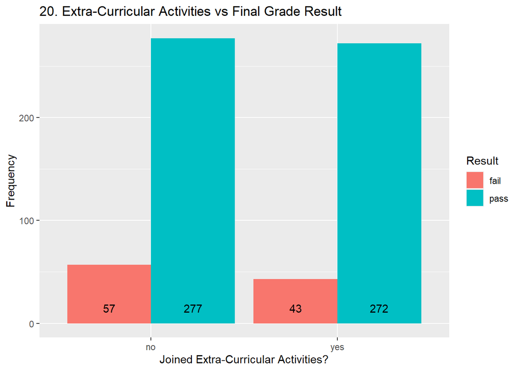

```r
bar.bivar <- Unstacked_bi_bar_graph(df$activities, df$result)
bar.bivar <- bar.bivar + ggtitle(label = "20. Extra-Curricular Activities vs Final Grade Result") +
  labs(x = "Joined Extra-Curricular Activities?")
bar.bivar
```

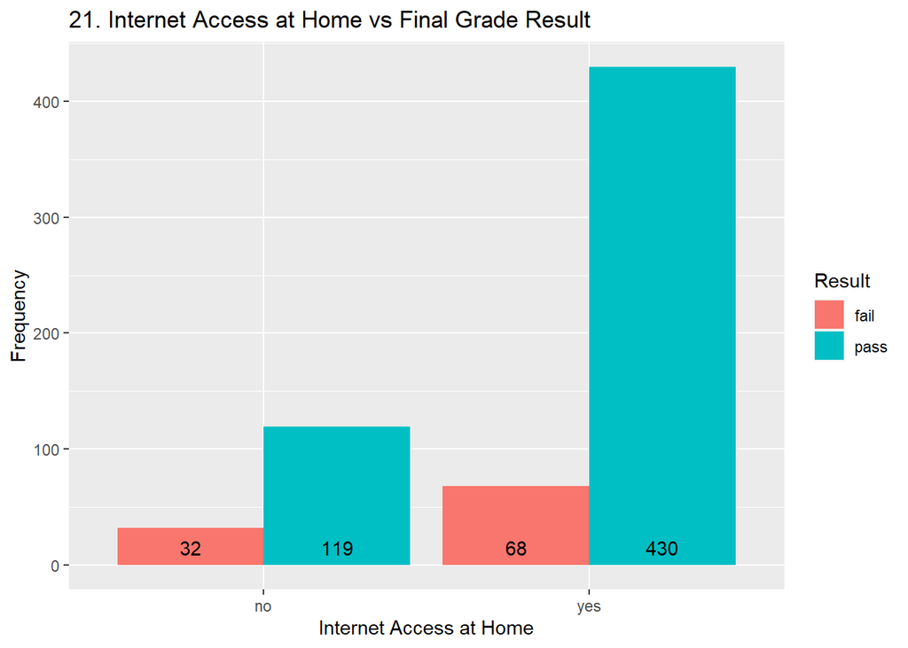

```r
bar.bivar <- Unstacked_bi_bar_graph(df$internet, df$result)
bar.bivar <- bar.bivar + ggtitle(label = "21. Internet Access at Home vs Final Grade Result") +
  labs(x = "Internet Access at Home")
bar.bivar
```

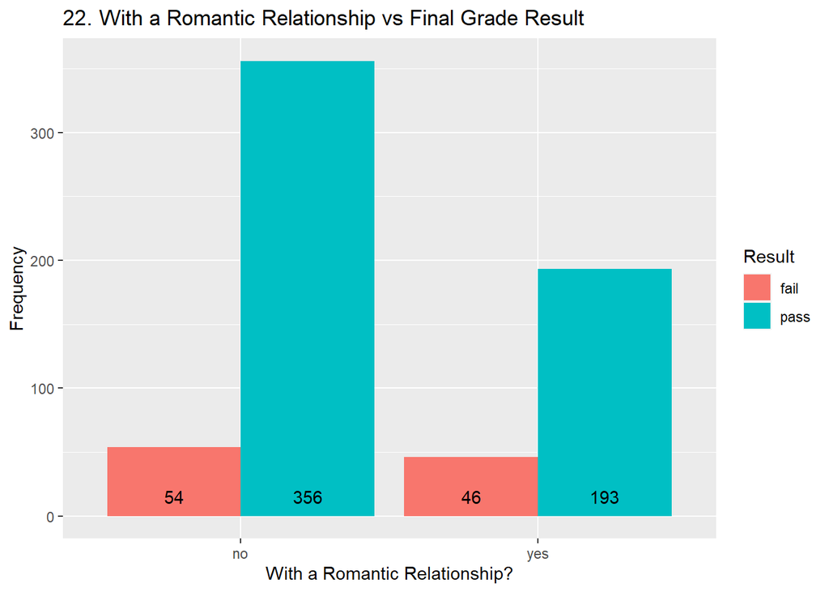

```r
bar.bivar <- Unstacked_bi_bar_graph(df$romantic, df$result)
bar.bivar <- bar.bivar + ggtitle(label = "22. With a Romantic Relationship vs Final Grade Result") +
  labs(x = "With a Romantic Relationship?")
bar.bivar
```

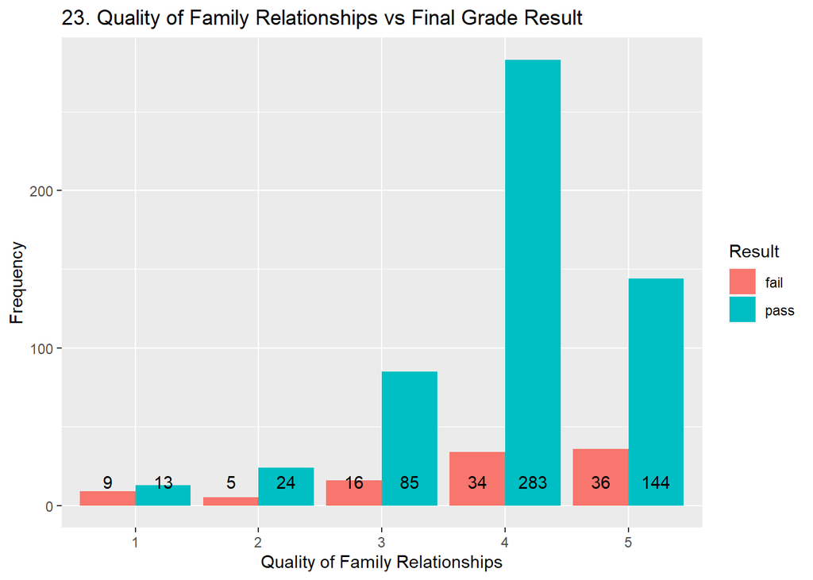

```r
bar.bivar <- Unstacked_bi_bar_graph(df$famrel, df$result)
bar.bivar <- bar.bivar + ggtitle(label = "23. Quality of Family Relationships vs Final Grade Result") + labs(x = "Quality of Family Relationships")
bar.bivar
```

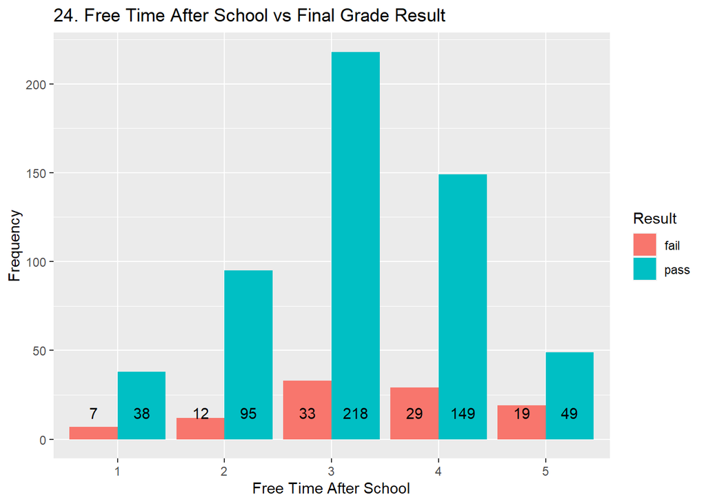

```r
bar.bivar <- Unstacked_bi_bar_graph(df$freetime, df$result)
bar.bivar <- bar.bivar + ggtitle(label = "24. Free Time After School vs Final Grade Result") +
  labs(x = "Free Time After School")
bar.bivar
```

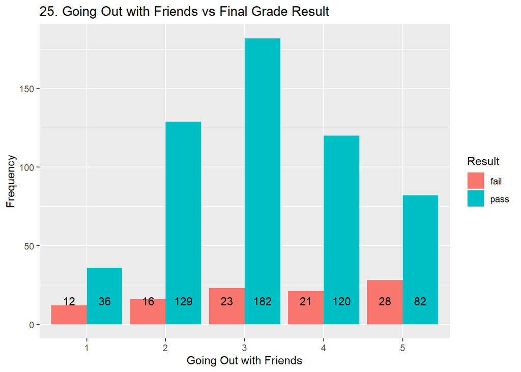

```r
bar.bivar <- Unstacked_bi_bar_graph(df$goout, df$result)
bar.bivar <- bar.bivar + ggtitle(label = "25. Going Out with Friends vs Final Grade Result") +
  labs(x = "Going Out with Friends")
bar.bivar
```

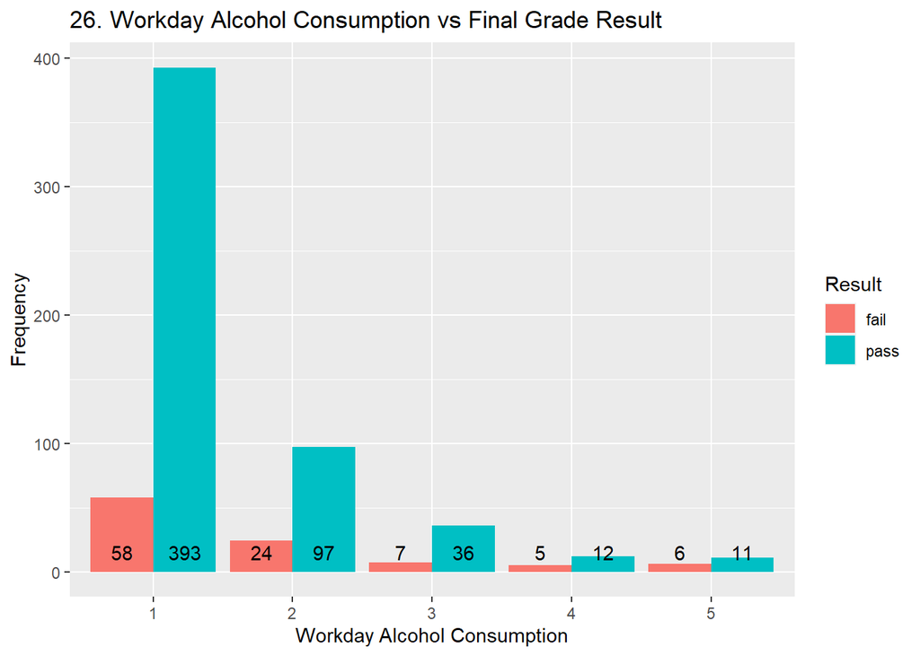

```r
bar.bivar <- Unstacked_bi_bar_graph(df$Dalc, df$result)
bar.bivar <- bar.bivar + ggtitle(label = "26. Workday Alcohol Consumption vs Final Grade Result") +
  labs(x = "Workday Alcohol Consumption")
bar.bivar
```

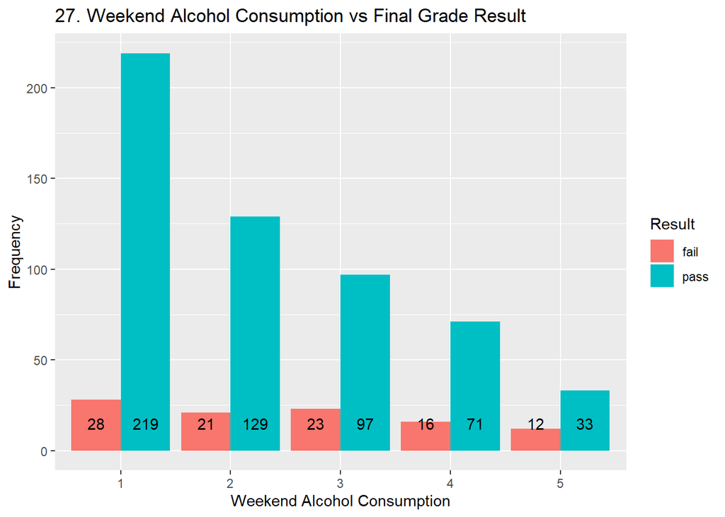

```r
bar.bivar <- Unstacked_bi_bar_graph(df$Walc, df$result)
bar.bivar <- bar.bivar + ggtitle(label = "27. Weekend Alcohol Consumption vs Final Grade Result") +
  labs(x = "Weekend Alcohol Consumption")
bar.bivar
```

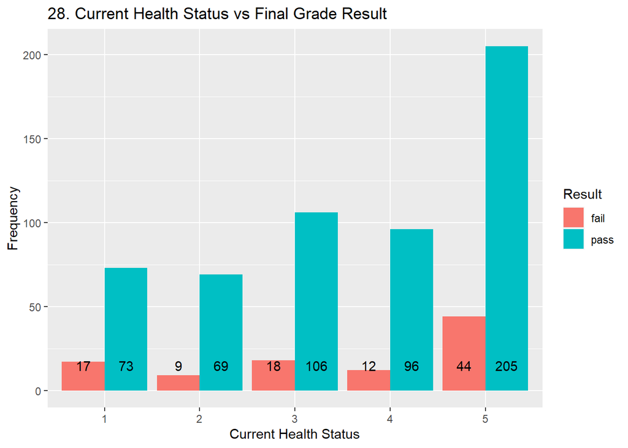

```r
bar.bivar <- Unstacked_bi_bar_graph(df$health, df$result)
bar.bivar <- bar.bivar + ggtitle(label = "28. Current Health Status vs Final Grade Result") +
  labs(x = "Current Health Status")
bar.bivar
```

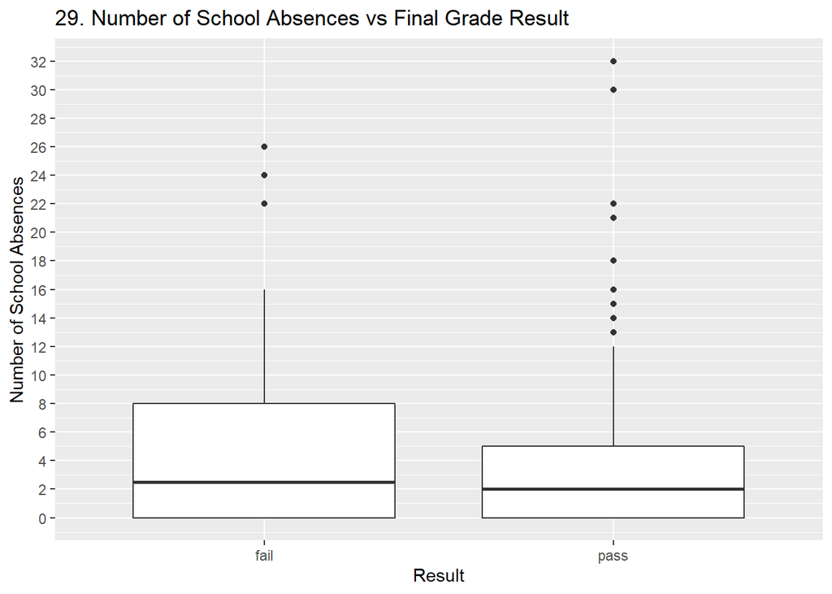

```r
ggplot(df, aes(y = absences, x = result)) +
  geom_boxplot() +
  ggtitle(label = "29. Number of School Absences vs Final Grade Result") +
  labs(y = "Number of School Absences", x = "Result") +
  scale_y_continuous(breaks = seq(0, 36, by = 2))
```

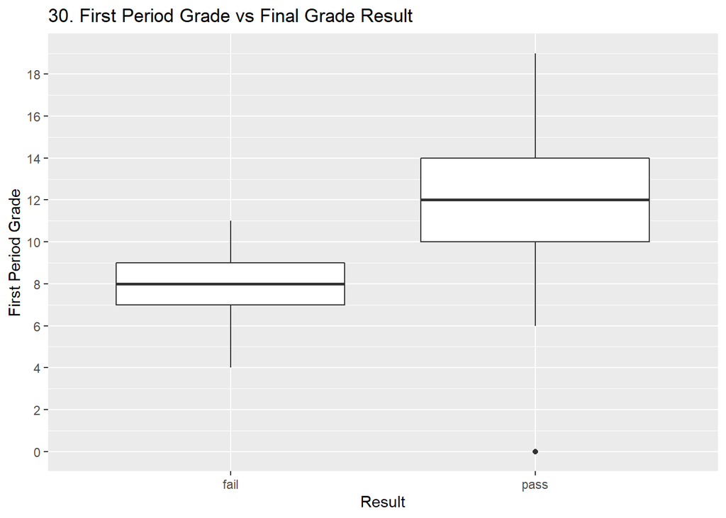

```r
ggplot(df, aes(y = G1, x = result)) +
  geom_boxplot() +
  labs(
    title = "30. First Period Grade vs Final Grade Result",
    y = "First Period Grade",
    x = "Result"
  ) +
  scale_y_continuous(breaks = seq(0, 22, by = 2))
```

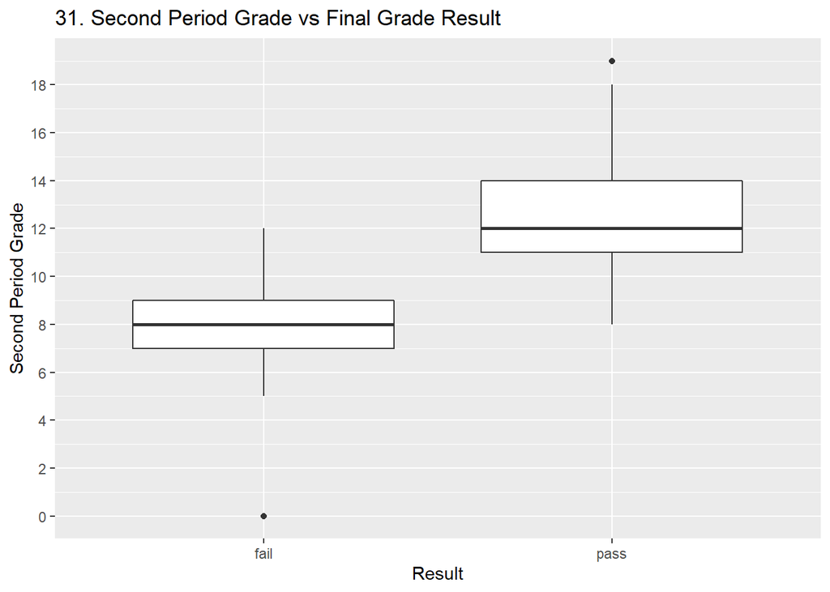

```r
ggplot(df, aes(y = G2, x = result)) +
  geom_boxplot() +
  labs(
    title = "31. Second Period Grade vs Final Grade Result",
    y = "Second Period Grade",
    x = "Result"
  ) +
  scale_y_continuous(breaks = seq(0, 22, by = 2))
```

### Correlation Analysis

Change processed dataset to matrix as ‘heat_map_data’.

```r
heat_map_data <- df %>% select(-1)
heat_map_data <- data.matrix(heat_map_data)
str(heat_map_data)
```

```
##  int [1:649, 1:33] 1 1 1 1 1 2 2 1 2 2 ...
##  - attr(*, "dimnames")=List of 2
##   ..$ : NULL
##   ..$ : chr [1:33] "sex" "age" "address" "famsize" ...
```

Calculate the correlation value for each attribute.

```r
heat_map_data <- round(cor(heat_map_data, method = "pearson"), 2)
head(heat_map_data)
```

```
##           sex   age address famsize Pstatus  Medu  Fedu  Mjob  Fjob reason
## sex      1.00 -0.04    0.03   -0.10    0.06  0.12  0.08  0.15  0.08   0.01
## age     -0.04  1.00   -0.03    0.00   -0.01 -0.11 -0.12 -0.07 -0.05  -0.03
## address  0.03 -0.03    1.00   -0.05   -0.09  0.19  0.14  0.16 -0.01   0.00
## famsize -0.10  0.00   -0.05    1.00    0.24  0.01  0.04 -0.02  0.06  -0.03
## Pstatus  0.06 -0.01   -0.09    0.24    1.00 -0.06 -0.03 -0.03  0.05  -0.03
## Medu     0.12 -0.11    0.19    0.01   -0.06  1.00  0.65  0.46  0.15   0.13
##         guardian traveltime studytime failures schoolsup famsup  paid
## sex        -0.04       0.04     -0.21     0.07     -0.11  -0.13  0.08
## age         0.27       0.03     -0.01     0.32     -0.17  -0.10 -0.01
## address    -0.02      -0.34      0.06    -0.06      0.02   0.01 -0.03
## famsize     0.00      -0.01      0.01     0.07      0.06   0.04  0.05
## Pstatus    -0.17       0.04     -0.01    -0.01     -0.01   0.01  0.02
## Medu       -0.01      -0.27      0.10    -0.17     -0.02   0.12  0.11
##         activities nursery higher internet romantic famrel freetime goout  Dalc
## sex           0.12   -0.04  -0.06     0.07    -0.11   0.08     0.15  0.06  0.28
## age          -0.05   -0.02  -0.27     0.01     0.18  -0.02     0.00  0.11  0.13
## address      -0.01    0.02   0.08     0.18    -0.03  -0.03    -0.04  0.02 -0.05
## famsize       0.01   -0.10   0.00    -0.01     0.03   0.00     0.02  0.00 -0.06
## Pstatus       0.10   -0.03   0.02     0.06    -0.05   0.05     0.04  0.03  0.04
## Medu          0.12    0.13   0.21     0.27    -0.03   0.02    -0.02  0.01 -0.01
##          Walc health absences    G1    G2    G3 result
## sex      0.32   0.14     0.02 -0.10 -0.10 -0.13  -0.08
## age      0.09  -0.01     0.15 -0.17 -0.11 -0.11  -0.11
## address -0.01   0.00     0.07  0.16  0.15  0.17   0.13
## famsize -0.08   0.00     0.00 -0.05 -0.04 -0.05  -0.05
## Pstatus  0.07   0.01    -0.12  0.02  0.02  0.00   0.00
## Medu    -0.02   0.00    -0.01  0.26  0.26  0.24   0.14
```

Change the matrix student_pro from short data to long data.

```r
heat_map_data <- melt(heat_map_data)
head(heat_map_data)
```

```
##        X1  X2 value
## 1     sex sex  1.00
## 2     age sex -0.04
## 3 address sex  0.03
## 4 famsize sex -0.10
## 5 Pstatus sex  0.06
## 6    Medu sex  0.12
```

Plot the heat map.

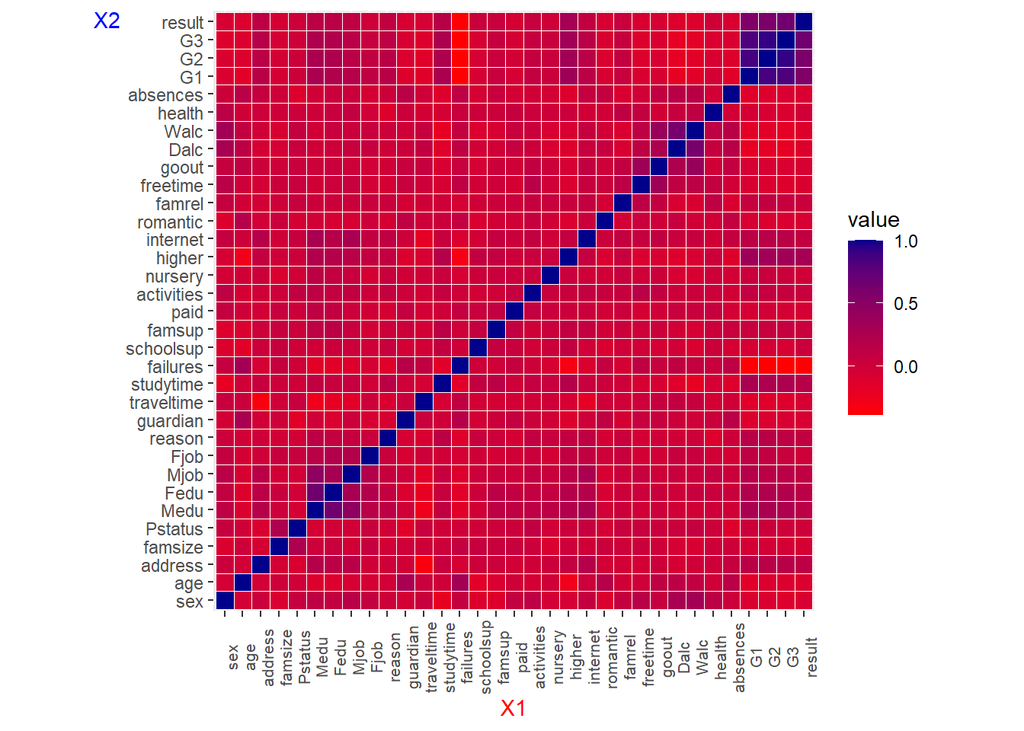

```r
heatmap <- ggplot(data = heat_map_data, aes(x = X1, y = X2, fill = value)) +
  geom_tile(color = "white") +
  scale_fill_gradient(low = "red", high = "darkblue") +
  theme(
    axis.text.x = element_text(angle = 90, size = 8),
    axis.title.x = element_text(angle = 0, color = "red"),
    axis.title.y = element_text(angle = 360, color = "blue")
  ) +
  coord_equal()
heatmap
```

Only show the absolute correlation value of G3 with Descending order.

```r
G3 <- subset(heat_map_data, X1 == "G3")
G3[3] <- abs(G3[3])
G3 <- G3[order(G3[, 3], decreasing = TRUE), ]
G3
```

```
##      X1         X2 value
## 1055 G3         G3  1.00
## 1022 G3         G2  0.92
## 989  G3         G1  0.83
## 1088 G3     result  0.66
## 461  G3   failures  0.39
## 659  G3     higher  0.33
## 428  G3  studytime  0.25
## 197  G3       Medu  0.24
## 230  G3       Fedu  0.21
## 857  G3       Dalc  0.20
## 890  G3       Walc  0.18
## 98   G3    address  0.17
## 263  G3       Mjob  0.15
## 692  G3   internet  0.15
```

[output cut: 19 more lines]

### Train-Test Split

Create train set and test set for regression and classification respectively.

#### Regression

```r
df_reg <- df

df_reg$result <- NULL

set.seed(42)

train_index_reg <- createDataPartition(
  df_reg$G3,
  p = 0.8,
  list = FALSE,
  times = 1
)

train_set_reg <- df_reg[train_index_reg, ]
test_set_reg <- df_reg[-train_index_reg, ]
```

#### Classification

```r
df_clf <- df

df_clf$G3 <- NULL

set.seed(42)

train_index_clf <- createDataPartition(
  df_clf$result,
  p = 0.8,
  list = FALSE,
  times = 1
)

train_set_clf <- df_clf[train_index_clf, ]
test_set_clf <- df_clf[-train_index_clf, ]
```

### Subsampling

Since we are dealing with imbalanced classes, we explore subsampling techniques for classification.

#### Original Sample

```r
table(train_set_clf$result)
```

```
##
## fail pass
##   80  440
```

#### Down-Sampling

```r
set.seed(42)

train_set_clf_down <- downSample(
  x = train_set_clf[, -ncol(train_set_clf)],
  y = train_set_clf$result,
  yname = "result"
)

table(train_set_clf_down$result)
```

```
##
## fail pass
##   80   80
```

#### Up-Sampling

```r
set.seed(42)

train_set_clf_up <- upSample(
  x = train_set_clf[, -ncol(train_set_clf)],
  y = train_set_clf$result,
  yname = "result"
)

table(train_set_clf_up$result)
```

```
##
## fail pass
##  440  440
```

### Modeling

Define repeated 10-fold cross validation.

```r
fit_control <- trainControl(
  method = "repeatedcv",
  number = 10,
  repeats = 10
)
```

#### Regression

Helper function for regression models

```r
train_evaluate_reg <- function(method = "", data = train_set_reg, tuneGrid = NULL, tuneLength = NULL, name = "") {
  set.seed(42)

  fit <- train(
    G3 ~ .,
    data = data,
    method = method,
    trControl = fit_control,
    preProcess = c("center", "scale"),
    tuneGrid = tuneGrid,
    tuneLength = tuneLength
  )
  print(fit)

  pred <- predict(fit, test_set_reg)
  result <- postResample(pred = pred, obs = test_set_reg$G3)

  metrics <- data.frame(
    Model = name,
    RMSE = result[["RMSE"]],
    Rsquared = result[["Rsquared"]],
    MAE = result[["MAE"]]
  )

  return(
    list(
      model = fit,
      metrics = metrics
    )
  )
}
```

```r
get_best_result <- function(caret_fit) {
  best <- which(rownames(caret_fit$results) == rownames(caret_fit$bestTune))
  best_result <- caret_fit$results[best, ]
  rownames(best_result) <- NULL
  best_result
}
```

#### 1. Decision Tree

CART

- method = ‘rpart’
- Type: Regression, Classification
- Tuning parameters:
  - cp (Complexity Parameter)
- Required packages: rpart
- A model-specific variable importance metric is available.

Training model with auto tuning:

```r
dt_reg <- train_evaluate_reg("rpart", name = "Decision Tree", tuneLength = 10)
```

```
## CART
##
## 520 samples
##  32 predictor
##
## Pre-processing: centered (72), scaled (72)
## Resampling: Cross-Validated (10 fold, repeated 10 times)
## Summary of sample sizes: 467, 469, 467, 468, 469, 469, ...
## Resampling results across tuning parameters:
##
##   cp           RMSE      Rsquared   MAE
##   0.002557381  1.511393  0.7924958  0.9036204
##   0.002711357  1.510197  0.7929802  0.9011272
##   0.005577788  1.480733  0.8000066  0.8637666
##   0.013277533  1.527893  0.7858778  0.9042992
##   0.013807340  1.534900  0.7842550  0.9149780
##   0.022095544  1.594516  0.7664695  1.0153027
##   0.053870748  1.745563  0.7258779  1.1300192
##   0.091924350  1.911984  0.6642470  1.3105574
##   0.127582534  2.194760  0.5633255  1.5491983
##   0.522696343  2.771181  0.4965485  2.0307630
##
## RMSE was used to select the optimal model using the smallest value.
## The final value used for the model was cp = 0.005577788.
```

Best parameters from tuning:

```r
get_best_result(dt_reg$model)
```

```
##            cp     RMSE  Rsquared       MAE    RMSESD RsquaredSD     MAESD
## 1 0.005577788 1.480733 0.8000066 0.8637666 0.3764418 0.08400127 0.1518122
```

Plot the trained model:

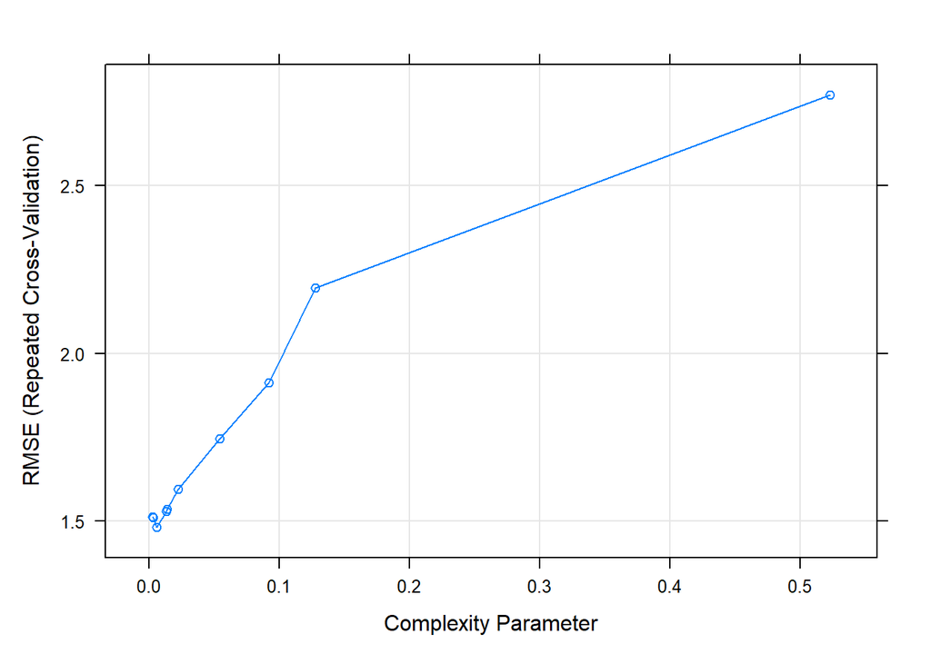

```r
plot(dt_reg$model)
```

- Value 0.005577788 is the optimal value for complexity parameter.

Evaluation of model:

```r
dt_reg$metrics
```

```
##           Model     RMSE  Rsquared      MAE
## 1 Decision Tree 1.340746 0.8114244 0.861462
```

#### 2. Random Forest

Random Forest

- method = ‘ranger’
- Type: Classification, Regression
- Tuning parameters:
  - mtry (#Randomly Selected Predictors) (Number of variables randomly sampled as candidates at each split.)
  - splitrule (Splitting Rule)
  - min.node.size (Minimal Node Size)
- Required packages: e1071, ranger, dplyr
- A model-specific variable importance metric is available.

Training model with auto tuning:

```r
rf_reg <- train_evaluate_reg("ranger", name = "Random Forest", tuneLength = 10)
```

```
## Random Forest
##
## 520 samples
##  32 predictor
##
## Pre-processing: centered (72), scaled (72)
## Resampling: Cross-Validated (10 fold, repeated 10 times)
## Summary of sample sizes: 467, 469, 467, 468, 469, 469, ...
## Resampling results across tuning parameters:
##
##   mtry  splitrule   RMSE      Rsquared   MAE
##    2    variance    2.361082  0.5965337  1.6083866
##    2    extratrees  2.510659  0.5538075  1.7610333
##    9    variance    1.671533  0.7692800  1.0813811
##    9    extratrees  1.844648  0.7384919  1.2565375
##   17    variance    1.458251  0.8115059  0.9221814
##   17    extratrees  1.571260  0.7925544  1.0201987
##   25    variance    1.382811  0.8255016  0.8781849
##   25    extratrees  1.452196  0.8132295  0.9186745
##   33    variance    1.349965  0.8314621  0.8630600
##   33    extratrees  1.395685  0.8225973  0.8814960
##   40    variance    1.337174  0.8335206  0.8572666
##   40    extratrees  1.364251  0.8279827  0.8666393
##   48    variance    1.332195  0.8340520  0.8557826
##   48    extratrees  1.347049  0.8312339  0.8624743
##   56    variance    1.334484  0.8331868  0.8596320
##   56    extratrees  1.334864  0.8334659  0.8613067
##   64    variance    1.341194  0.8311826  0.8630732
##   64    extratrees  1.327816  0.8346144  0.8608048
##   72    variance    1.356029  0.8277105  0.8705985
##   72    extratrees  1.328030  0.8342539  0.8635932
##
## Tuning parameter 'min.node.size' was held constant at a value of 5
## RMSE was used to select the optimal model using the smallest value.
## The final values used for the model were mtry = 64, splitrule = extratrees
##  and min.node.size = 5.
```

Best parameters from tuning:

```r
get_best_result(rf_reg$model)
```

```
##   mtry min.node.size  splitrule     RMSE  Rsquared       MAE   RMSESD
## 1   64             5 extratrees 1.327816 0.8346144 0.8608048 0.355189
##   RsquaredSD     MAESD
## 1 0.07199443 0.1303264
```

Plot the trained model:

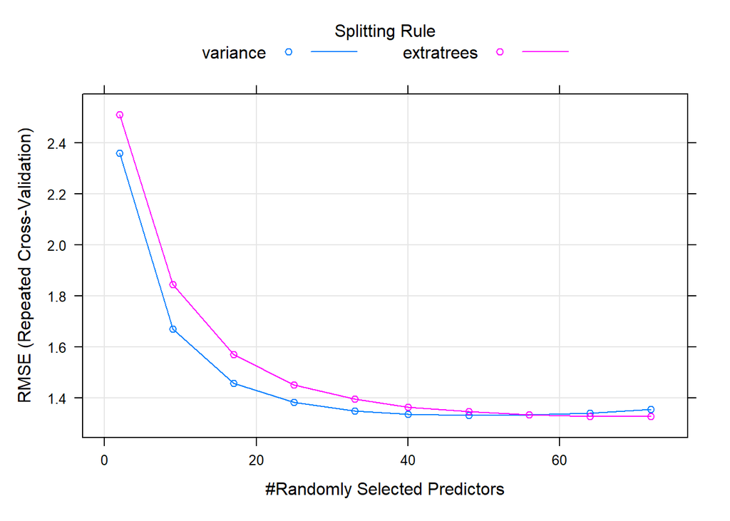

```r
plot(rf_reg$model)
```

- For splitrule (splitting rule) = variance, mtry = 48 is already the optimal value.
- For splitrule (splitting rule) = extratrees, mtry = 64. Can try to tune with mtry between 64 and 72 (max mtry = 72).
- Tuning parameter ‘min.node.size’ was held constant at a value of 5, can try to tune with other values.

Training model with manual tuning:

- splitrule = variance or extratrees
- mtry between 48 to 72
- min.node.size between 1 to 10

```r
tuneGrid_rf_reg <- expand.grid(
  splitrule = c("variance", "extratrees"),
  mtry = seq(48, 72, by = 2),
  min.node.size = seq(1, 10)
)

rf_reg_manual_tune <- train_evaluate_reg("ranger", name = "Random Forest", tuneGrid = tuneGrid_rf_reg)
```

```
## Random Forest
##
## 520 samples
##  32 predictor
##
## Pre-processing: centered (72), scaled (72)
## Resampling: Cross-Validated (10 fold, repeated 10 times)
## Summary of sample sizes: 467, 469, 467, 468, 469, 469, ...
## Resampling results across tuning parameters:
##
##   splitrule   mtry  min.node.size  RMSE      Rsquared   MAE
##   variance    48     1             1.339687  0.8321916  0.8600324
##   variance    48     2             1.336134  0.8332092  0.8592320
##   variance    48     3             1.333500  0.8336435  0.8559939
##   variance    48     4             1.334916  0.8332117  0.8589217
##   variance    48     5             1.332246  0.8340008  0.8572885
##   variance    48     6             1.331247  0.8343653  0.8556232
##   variance    48     7             1.328390  0.8350604  0.8553474
##   variance    48     8             1.328514  0.8350560  0.8533839
##   variance    48     9             1.326800  0.8354832  0.8535098
##   variance    48    10             1.324920  0.8360505  0.8524417
##   variance    50     1             1.335152  0.8331818  0.8593207
##   variance    50     2             1.333297  0.8335790  0.8567243
##   variance    50     3             1.334035  0.8335643  0.8578439
##   variance    50     4             1.332929  0.8338782  0.8566703
##   variance    50     5             1.327261  0.8351136  0.8554863
##   variance    50     6             1.332834  0.8337942  0.8569689
##   variance    50     7             1.328753  0.8348733  0.8543881
##   variance    50     8             1.328750  0.8347862  0.8552245
##   variance    50     9             1.327696  0.8351239  0.8535439
##   variance    50    10             1.326696  0.8352006  0.8531400
##   variance    52     1             1.339058  0.8321510  0.8613817
##   variance    52     2             1.335897  0.8328892  0.8592826
##   variance    52     3             1.336815  0.8327205  0.8586926
##   variance    52     4             1.334774  0.8333031  0.8586056
##   variance    52     5             1.330411  0.8342853  0.8565100
##   variance    52     6             1.332062  0.8338640  0.8567949
##   variance    52     7             1.329409  0.8346121  0.8545169
##   variance    52     8             1.326546  0.8353887  0.8544571
##   variance    52     9             1.326604  0.8352086  0.8547701
```

[output cut: 220 more lines]

```
##   extratrees  70    10             1.319497  0.8363125  0.8562400
##   extratrees  72     1             1.330268  0.8334010  0.8628994
##   extratrees  72     2             1.329614  0.8335267  0.8637409
##   extratrees  72     3             1.328619  0.8338012  0.8621581
##   extratrees  72     4             1.325283  0.8348138  0.8597814
##   extratrees  72     5             1.327494  0.8342769  0.8617857
##   extratrees  72     6             1.327317  0.8342458  0.8615627
##   extratrees  72     7             1.323704  0.8352427  0.8596404
##   extratrees  72     8             1.323539  0.8352105  0.8584455
##   extratrees  72     9             1.317547  0.8365602  0.8551783
##   extratrees  72    10             1.319702  0.8362721  0.8554894
##
## RMSE was used to select the optimal model using the smallest value.
## The final values used for the model were mtry = 72, splitrule = extratrees
##  and min.node.size = 9.
```

Best parameters from tuning:

```r
get_best_result(rf_reg_manual_tune$model)
```

```
##    splitrule mtry min.node.size     RMSE  Rsquared       MAE    RMSESD
## 1 extratrees   72             9 1.317547 0.8365602 0.8551783 0.3567946
##   RsquaredSD     MAESD
## 1 0.07302355 0.1312441
```

Plot the trained model:

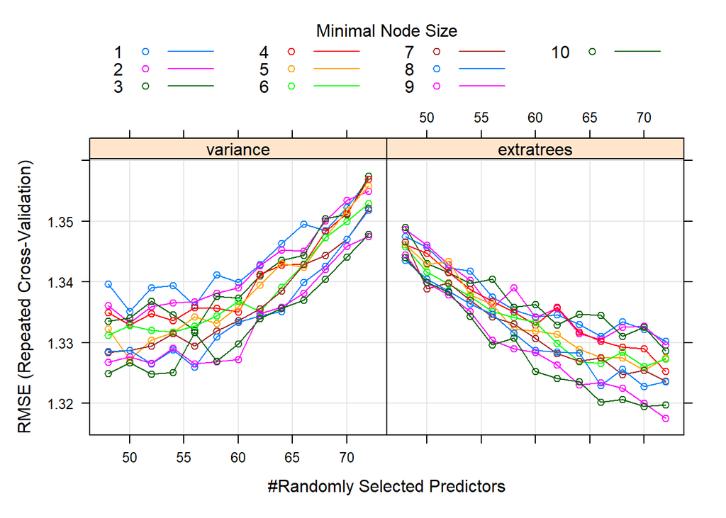

```r
plot(rf_reg_manual_tune$model)
```

Optimal value for each parameters:

- mtry = 72
- splitrule = extratrees
- min.node.size = 9

Evaluation of model:

```r
rf_reg_manual_tune$metrics
```

```
##           Model     RMSE  Rsquared      MAE
## 1 Random Forest 1.106174 0.8666637 0.771789
```

#### 3. SVM with Polynomial Kernel

Support Vector Machines with Polynomial Kernel

- method = ‘svmPoly’
- Type: Regression, Classification
- Tuning parameters:
  - degree (Polynomial Degree)
  - scale (Scale)
  - C (Cost)
- Required packages: kernlab

Training model with auto tuning:

- We have tried with tuneLength of 10, unfortunately it took too much of time to finish, thus we have decided to go with tuneLength of 5 in SVM.

```r
svm_reg <- train_evaluate_reg("svmPoly", name = "Support Vector Machine", tuneLength = 5)
```

```
## Support Vector Machines with Polynomial Kernel
##
## 520 samples
##  32 predictor
##
## Pre-processing: centered (72), scaled (72)
## Resampling: Cross-Validated (10 fold, repeated 10 times)
## Summary of sample sizes: 467, 469, 467, 468, 469, 469, ...
## Resampling results across tuning parameters:
##
##   degree  scale  C     RMSE      Rsquared   MAE
##   1       1e-03  0.25  2.549829  0.6456328  1.7925306
##   1       1e-03  0.50  2.211695  0.7116538  1.5148416
##   1       1e-03  1.00  1.850422  0.7721718  1.2223146
##   1       1e-03  2.00  1.576803  0.8051574  0.9973955
```

[output cut: 74 more lines]

Best parameters from tuning:

```r
get_best_result(svm_reg$model)
```

```
##   degree scale    C     RMSE  Rsquared       MAE    RMSESD RsquaredSD     MAESD
## 1      1    10 0.25 1.323996 0.8326103 0.8417843 0.3969325 0.08127431 0.1390743
```

Plot the trained model:

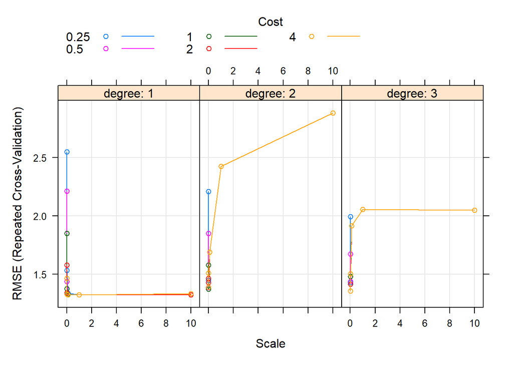

```r
plot(svm_reg$model)
```

- The parameters degree (Polynomial Degree) = 1, scale = 10, and C (Cost) = 0.25 reached their optimal value.

Evaluation of model:

```r
svm_reg$metrics
```

```
##                    Model     RMSE  Rsquared       MAE
## 1 Support Vector Machine 1.177426 0.8521626 0.7618882
```

#### 4. XGBoost

- method = ‘xgbLinear’
- Type: Regression, Classification
- Tuning parameters:
  - nrounds (#Boosting Iterations)
  - lambda (L2 Regularization)
  - alpha (L1 Regularization)
  - eta (Learning Rate)
- Required packages: xgboost
- A model-specific variable importance metric is available.

Training model with auto tuning:

```r
xgb_reg <- train_evaluate_reg("xgbLinear", name = "XGBoost", tuneLength = 3)
```

```
## eXtreme Gradient Boosting
##
## 520 samples
##  32 predictor
##
## Pre-processing: centered (72), scaled (72)
## Resampling: Cross-Validated (10 fold, repeated 10 times)
## Summary of sample sizes: 467, 469, 467, 468, 469, 469, ...
## Resampling results across tuning parameters:
##
##   lambda  alpha  nrounds  RMSE      Rsquared   MAE
##   0e+00   0e+00   50      1.511613  0.7918378  0.9393092
##   0e+00   0e+00  100      1.512005  0.7917418  0.9397081
##   0e+00   0e+00  150      1.512005  0.7917418  0.9397081
##   0e+00   1e-04   50      1.505989  0.7930916  0.9383068
##   0e+00   1e-04  100      1.506339  0.7930240  0.9387463
##   0e+00   1e-04  150      1.506339  0.7930240  0.9387465
##   0e+00   1e-01   50      1.510758  0.7910783  0.9447155
##   0e+00   1e-01  100      1.510970  0.7910251  0.9449051
##   0e+00   1e-01  150      1.510970  0.7910251  0.9449051
##   1e-04   0e+00   50      1.506888  0.7926763  0.9373235
##   1e-04   0e+00  100      1.507267  0.7925891  0.9377648
##   1e-04   0e+00  150      1.507267  0.7925891  0.9377648
##   1e-04   1e-04   50      1.508816  0.7921554  0.9391927
##   1e-04   1e-04  100      1.509250  0.7920720  0.9397714
##   1e-04   1e-04  150      1.509250  0.7920720  0.9397714
##   1e-04   1e-01   50      1.507130  0.7922016  0.9429704
##   1e-04   1e-01  100      1.507336  0.7921494  0.9432016
##   1e-04   1e-01  150      1.507336  0.7921494  0.9432016
##   1e-01   0e+00   50      1.499107  0.7932489  0.9410474
##   1e-01   0e+00  100      1.499690  0.7931013  0.9416606
##   1e-01   0e+00  150      1.499690  0.7931014  0.9416605
##   1e-01   1e-04   50      1.499257  0.7930752  0.9417873
##   1e-01   1e-04  100      1.500019  0.7928812  0.9425275
##   1e-01   1e-04  150      1.500019  0.7928811  0.9425286
##   1e-01   1e-01   50      1.491578  0.7960916  0.9394836
##   1e-01   1e-01  100      1.492072  0.7959774  0.9399642
##   1e-01   1e-01  150      1.492072  0.7959774  0.9399642
##
## Tuning parameter 'eta' was held constant at a value of 0.3
## RMSE was used to select the optimal model using the smallest value.
## The final values used for the model were nrounds = 50, lambda = 0.1, alpha
##  = 0.1 and eta = 0.3.
```

Best parameters from tuning:

```r
get_best_result(xgb_reg$model)
```

```
##   lambda alpha nrounds eta     RMSE  Rsquared       MAE    RMSESD RsquaredSD
## 1    0.1   0.1      50 0.3 1.491578 0.7960916 0.9394836 0.3821073 0.09009631
##       MAESD
## 1 0.1550427
```

Plot the trained model:

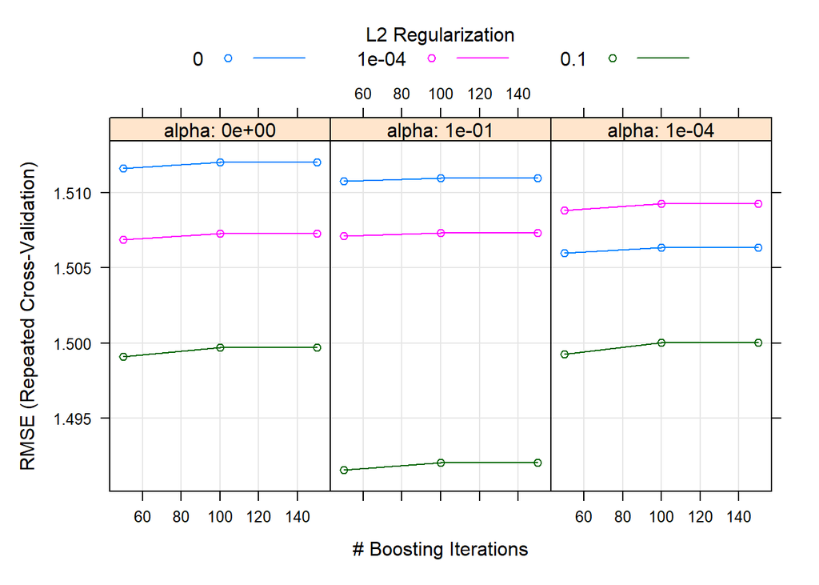

```r
plot(xgb_reg$model)
```

Training model with manual tuning:

```r
tuneGrid_xgb_reg <- expand.grid(
  eta = 0.3,
  lambda = 0.1,
  alpha = c(0.001, 0.01, 0.1),
  nrounds = seq(10, 70, 10)
)

xgb_reg_manual_tune <- train_evaluate_reg("xgbLinear", name = "XGBoost", tuneGrid = tuneGrid_xgb_reg)
```

```
## eXtreme Gradient Boosting
##
## 520 samples
##  32 predictor
##
## Pre-processing: centered (72), scaled (72)
## Resampling: Cross-Validated (10 fold, repeated 10 times)
## Summary of sample sizes: 467, 469, 467, 468, 469, 469, ...
## Resampling results across tuning parameters:
##
##   alpha  nrounds  RMSE      Rsquared   MAE
##   0.001  10       1.518110  0.7981275  0.9601702
##   0.001  20       1.490676  0.7950565  0.9326202
##   0.001  30       1.496577  0.7936059  0.9404913
##   0.001  40       1.498049  0.7932848  0.9418572
##   0.001  50       1.499322  0.7929895  0.9431174
##   0.001  60       1.499623  0.7929325  0.9435549
##   0.001  70       1.499770  0.7929032  0.9436339
##   0.010  10       1.518822  0.7984699  0.9556418
##   0.010  20       1.487909  0.7964229  0.9250986
##   0.010  30       1.494958  0.7947124  0.9316516
##   0.010  40       1.497355  0.7941440  0.9342274
##   0.010  50       1.498089  0.7939856  0.9350578
##   0.010  60       1.498446  0.7938916  0.9354407
##   0.010  70       1.498518  0.7938762  0.9355422
##   0.100  10       1.515027  0.8002019  0.9603495
##   0.100  20       1.484927  0.7975879  0.9298917
##   0.100  30       1.489417  0.7965265  0.9365004
##   0.100  40       1.490933  0.7962359  0.9383227
##   0.100  50       1.491578  0.7960916  0.9394836
##   0.100  60       1.492002  0.7959988  0.9399262
##   0.100  70       1.492072  0.7959768  0.9399641
##
## Tuning parameter 'lambda' was held constant at a value of 0.1
## Tuning
##  parameter 'eta' was held constant at a value of 0.3
## RMSE was used to select the optimal model using the smallest value.
## The final values used for the model were nrounds = 20, lambda = 0.1, alpha
##  = 0.1 and eta = 0.3.
```

Best parameters from tuning:

```r
get_best_result(xgb_reg_manual_tune$model)
```

```
##   eta lambda alpha nrounds     RMSE  Rsquared       MAE    RMSESD RsquaredSD
## 1 0.3    0.1   0.1      20 1.484927 0.7975879 0.9298917 0.3860466 0.09051595
##       MAESD
## 1 0.1561429
```

Plot the trained model:

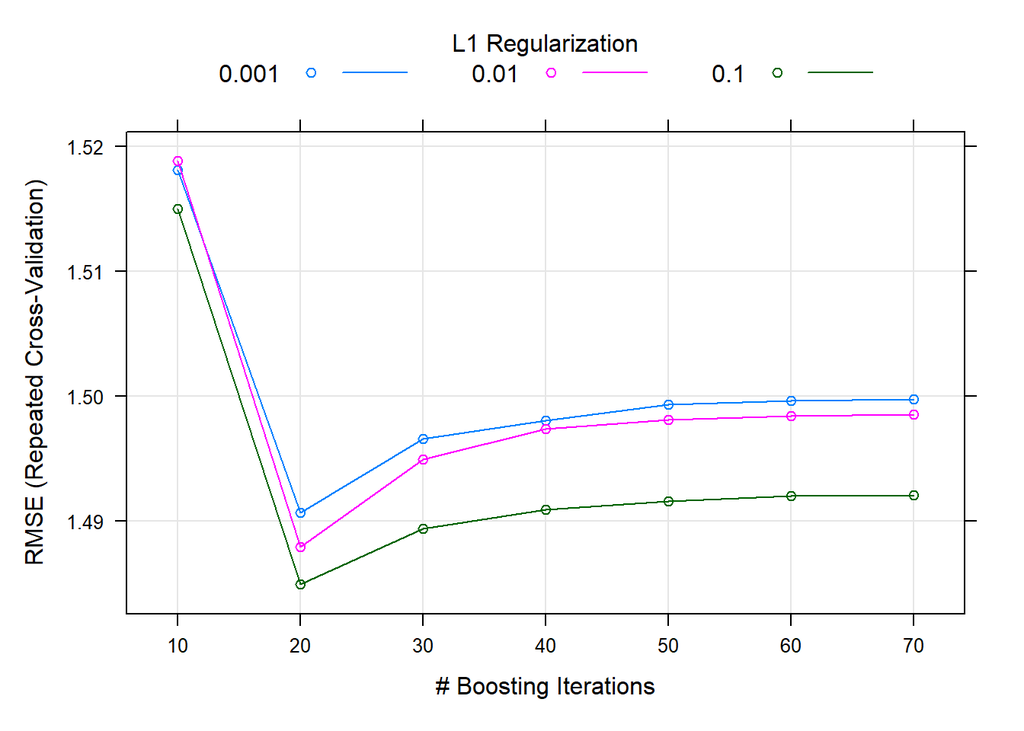

```r
plot(xgb_reg_manual_tune$model)
```

Evaluation of model:

```r
xgb_reg_manual_tune$metrics
```

```
##     Model     RMSE  Rsquared       MAE
## 1 XGBoost 1.250256 0.8338254 0.8697652
```

#### 5. Linear Regression with Regularization

- method = ‘glmnet’
- Type: Regression, Classification
- Tuning parameters:
  - alpha (Mixing Percentage)
  - lambda (Regularization Parameter)
- Required packages: glmnet, Matrix
- A model-specific variable importance metric is available.

Training model with auto tuning:

```r
lr_reg <- train_evaluate_reg("glmnet", name = "Linear Regression", tuneLength = 10)
```

```
## glmnet
##
## 520 samples
##  32 predictor
##
## Pre-processing: centered (72), scaled (72)
## Resampling: Cross-Validated (10 fold, repeated 10 times)
## Summary of sample sizes: 467, 469, 467, 468, 469, 469, ...
## Resampling results across tuning parameters:
##
##   alpha  lambda       RMSE      Rsquared   MAE
##   0.1    0.001388258  1.395236  0.8165417  0.9295931
##   0.1    0.003207056  1.395236  0.8165417  0.9295931
##   0.1    0.007408715  1.395236  0.8165417  0.9295931
##   0.1    0.017115092  1.391001  0.8174735  0.9254500
##   0.1    0.039538082  1.378930  0.8201344  0.9135626
##   0.1    0.091338097  1.359258  0.8246227  0.8937805
##   0.1    0.211002851  1.336974  0.8305641  0.8640433
##   0.1    0.487443953  1.334994  0.8354640  0.8454409
##   0.1    1.126058753  1.416341  0.8334863  0.9057614
##   0.1    2.601341770  1.661772  0.8275410  1.0899052
##   0.2    0.001388258  1.394987  0.8166643  0.9296277
##   0.2    0.003207056  1.394987  0.8166643  0.9296277
##   0.2    0.007408715  1.393455  0.8170050  0.9281990
##   0.2    0.017115092  1.383181  0.8193159  0.9185476
##   0.2    0.039538082  1.364119  0.8236290  0.9006899
##   0.2    0.091338097  1.333282  0.8307732  0.8684140
##   0.2    0.211002851  1.303239  0.8388678  0.8293382
##   0.2    0.487443953  1.317026  0.8419026  0.8219884
##   0.2    1.126058753  1.430309  0.8390100  0.8952581
##   0.2    2.601341770  1.753044  0.8379850  1.1504334
##   0.3    0.001388258  1.394869  0.8167031  0.9296248
##   0.3    0.003207056  1.394869  0.8167031  0.9296248
##   0.3    0.007408715  1.389865  0.8178422  0.9250100
##   0.3    0.017115092  1.376191  0.8209509  0.9124625
##   0.3    0.039538082  1.350549  0.8267956  0.8883604
##   0.3    0.091338097  1.313632  0.8353737  0.8489229
##   0.3    0.211002851  1.285210  0.8434454  0.8122952
##   0.3    0.487443953  1.315619  0.8441240  0.8123446
##   0.3    1.126058753  1.447786  0.8432459  0.9018030
```

[output cut: 59 more lines]

```
##   0.9    1.126058753  1.652316  0.8503275  1.0865619
##   0.9    2.601341770  2.704508  0.8492426  1.9770810
##   1.0    0.001388258  1.394612  0.8167989  0.9295231
##   1.0    0.003207056  1.386058  0.8187784  0.9218740
##   1.0    0.007408715  1.368660  0.8227886  0.9064881
##   1.0    0.017115092  1.336081  0.8301996  0.8752796
##   1.0    0.039538082  1.292377  0.8400863  0.8339090
##   1.0    0.091338097  1.263038  0.8471983  0.8052305
##   1.0    0.211002851  1.260452  0.8510329  0.7928667
##   1.0    0.487443953  1.333989  0.8508628  0.8276583
##   1.0    1.126058753  1.686923  0.8492426  1.1216198
##   1.0    2.601341770  2.893369  0.8492426  2.1324632
##
## RMSE was used to select the optimal model using the smallest value.
## The final values used for the model were alpha = 1 and lambda = 0.2110029.
```

Best parameters from tuning:

```r
get_best_result(lr_reg$model)
```

```
##   alpha    lambda     RMSE  Rsquared       MAE    RMSESD RsquaredSD     MAESD
## 1     1 0.2110029 1.260452 0.8510329 0.7928667 0.4019447 0.07640349 0.1336843
```

Plot the trained model:

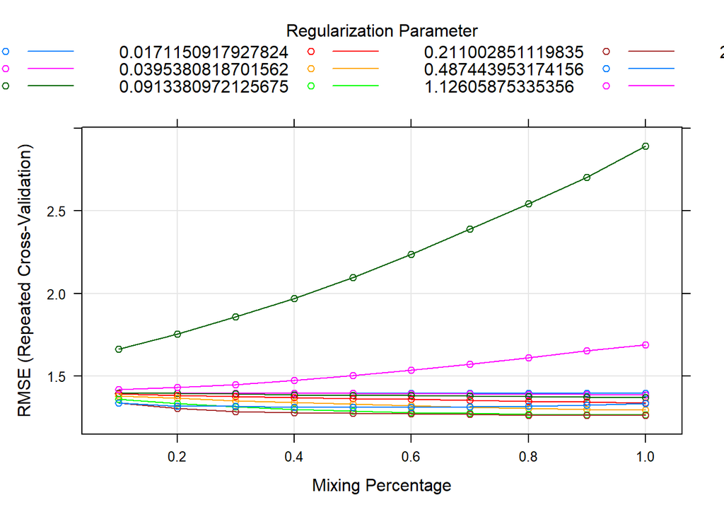

```r
plot(lr_reg$model)
```

- The parameter alpha (Mixing Percentage) = 1 is the optimal value while there’s possibility to get better result with lambda (Regularization Parameter) < 0.2110029.

Training model with manual tuning:

- alpha = 1
- lambda between 0.001 to 0.300

```r
tuneGrid_lr_reg <- expand.grid(
  alpha = c(1),
  lambda = seq(0.00, 0.30, by = 0.05)
)

lr_reg_manual_tune <- train_evaluate_reg("glmnet", name = "Linear Regression", tuneGrid = tuneGrid_lr_reg)
```

```
## glmnet
##
## 520 samples
##  32 predictor
##
## Pre-processing: centered (72), scaled (72)
## Resampling: Cross-Validated (10 fold, repeated 10 times)
## Summary of sample sizes: 467, 469, 467, 468, 469, 469, ...
## Resampling results across tuning parameters:
##
##   lambda  RMSE      Rsquared   MAE
##   0.00    1.394938  0.8167240  0.9298049
##   0.05    1.281021  0.8426330  0.8235131
##   0.10    1.261976  0.8476099  0.8039718
##   0.15    1.258282  0.8496377  0.7969222
##   0.20    1.259368  0.8508915  0.7932318
##   0.25    1.265253  0.8514903  0.7922721
##   0.30    1.274531  0.8517463  0.7938045
##
## Tuning parameter 'alpha' was held constant at a value of 1
## RMSE was used to select the optimal model using the smallest value.
## The final values used for the model were alpha = 1 and lambda = 0.15.
```

Best parameters from tuning:

```r
get_best_result(lr_reg_manual_tune$model)
```

```
##   alpha lambda     RMSE  Rsquared       MAE   RMSESD RsquaredSD     MAESD
## 1     1   0.15 1.258282 0.8496377 0.7969222 0.398786 0.07721303 0.1329245
```

Plot the trained model:

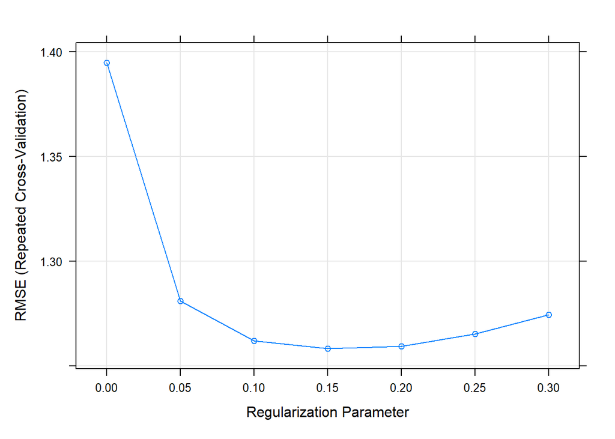

```r
plot(lr_reg_manual_tune$model)
```

- The parameter alpha (Mixing Percentage) = 1 and lambda (Regularization Parameter) = 0.15 reached their optimal value.

Evaluation of model:

```r
lr_reg_manual_tune$metrics
```

```
##               Model     RMSE  Rsquared       MAE
## 1 Linear Regression 1.117378 0.8643585 0.7226734
```

#### Classification

Define a helper function to train model.

```r
train_model_clf <- function(method = "",
                            data = train_set_clf,
                            tuneGrid = NULL,
                            tuneLength = 3) {
  set.seed(42)

  fit <- train(
    result ~ .,
    data = data,
    method = method,
    trControl = fit_control,
    preProcess = c("center", "scale"),
    tuneGrid = tuneGrid,
    tuneLength = tuneLength
  )

  print(fit)

  return(fit)
}
```

Define a helper function to evaluate model.

```r
evaluate_model_clf <- function(model = NULL, name = "") {
  pred <- predict(model, test_set_clf)

  cm_fail <- confusionMatrix(pred, test_set_clf$result, mode = "prec_recall")
  print(cm_fail)

  cm_pass <- confusionMatrix(
    pred,
    test_set_clf$result,
    mode = "prec_recall",
    positive = "pass"
  )

  return(data.frame(
    Model = name,
    Accuracy = round(cm_fail$overall[["Accuracy"]], 3),
    Precision.Fail = round(cm_fail$byClass[["Precision"]], 3),
    Recall.Fail = round(cm_fail$byClass[["Recall"]], 3),
    F1.Fail = round(cm_fail$byClass[["F1"]], 3),
    Precision.Pass = round(cm_pass$byClass[["Precision"]], 3),
    Recall.Pass = round(cm_pass$byClass[["Recall"]], 3),
    F1.Pass = round(cm_pass$byClass[["F1"]], 3)
  ))
}
```

#### 1. Decision Tree

- method = ‘rpart2’
- Type: Regression, Classification
- Tuning parameters:
  - maxdepth (Max Tree Depth)
- Required packages: rpart
- A model-specific variable importance metric is available.

##### Original Train Set

```r
dt_clf <- train_model_clf("rpart2")
```

```
## note: only 2 possible values of the max tree depth from the initial fit.
##  Truncating the grid to 2 .
##
## CART
##
## 520 samples
##  32 predictor
##   2 classes: 'fail', 'pass'
##
## Pre-processing: centered (72), scaled (72)
## Resampling: Cross-Validated (10 fold, repeated 10 times)
## Summary of sample sizes: 468, 468, 468, 468, 468, 468, ...
## Resampling results across tuning parameters:
##
##   maxdepth  Accuracy   Kappa
##   1         0.9365385  0.7199437
##   4         0.9286538  0.7122307
##
## Accuracy was used to select the optimal model using the largest value.
## The final value used for the model was maxdepth = 1.
```

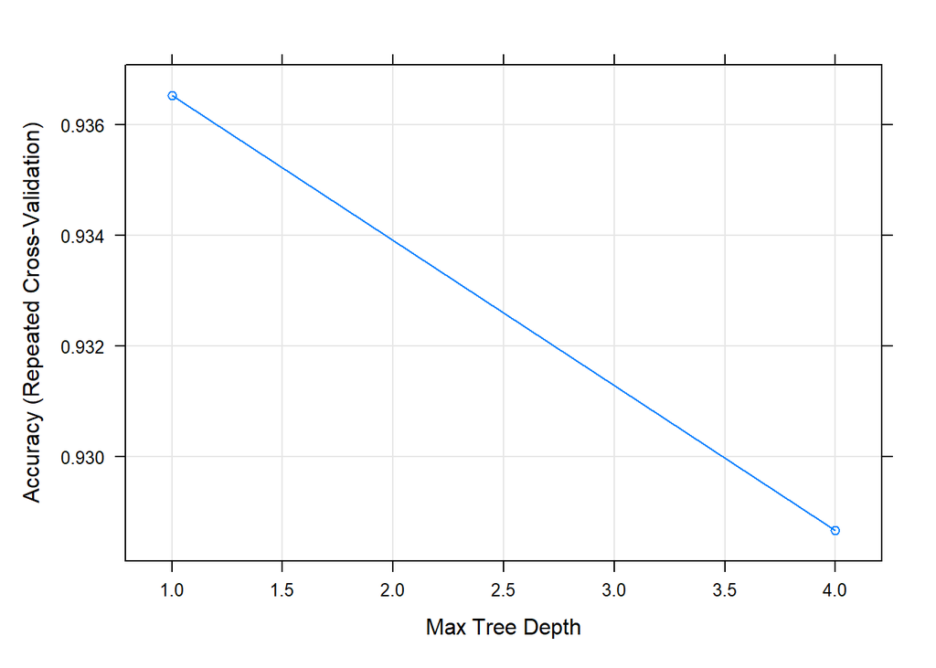

```r
plot(dt_clf)
```

No further tuning required.

```r
dt_metrics_clf <- evaluate_model_clf(dt_clf, "Decision Tree")
```

```
## Confusion Matrix and Statistics
##
##           Reference
## Prediction fail pass
##       fail   13    1
##       pass    7  108
##
##                Accuracy : 0.938
##                  95% CI : (0.8815, 0.9728)
##     No Information Rate : 0.845
##     P-Value [Acc > NIR] : 0.001075
##
##                   Kappa : 0.7303
##
##  Mcnemar's Test P-Value : 0.077100
##
##               Precision : 0.9286
##                  Recall : 0.6500
##                      F1 : 0.7647
##              Prevalence : 0.1550
##          Detection Rate : 0.1008
##    Detection Prevalence : 0.1085
##       Balanced Accuracy : 0.8204
##
##        'Positive' Class : fail
##
```

##### Down-Sampled Train Set

```r
down_dt_clf <- train_model_clf("rpart2", train_set_clf_down)
```

```
## note: only 2 possible values of the max tree depth from the initial fit.
##  Truncating the grid to 2 .
##
## CART
##
## 160 samples
##  32 predictor
##   2 classes: 'fail', 'pass'
##
## Pre-processing: centered (72), scaled (72)
## Resampling: Cross-Validated (10 fold, repeated 10 times)
## Summary of sample sizes: 144, 144, 144, 144, 144, 144, ...
## Resampling results across tuning parameters:
##
##   maxdepth  Accuracy  Kappa
##   1         0.838125  0.67625
##   2         0.823750  0.64750
##
## Accuracy was used to select the optimal model using the largest value.
## The final value used for the model was maxdepth = 1.
```

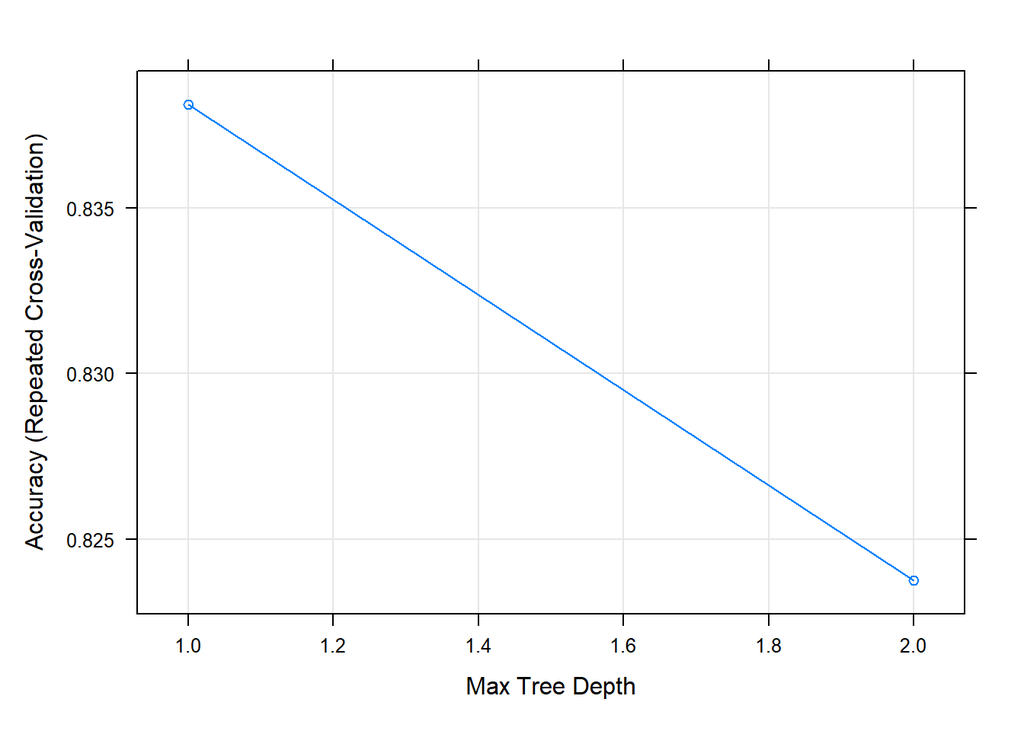

```r
plot(down_dt_clf)
```

No further tuning required.

```r
down_dt_metrics_clf <- evaluate_model_clf(down_dt_clf, "Decision Tree")
```

```
## Confusion Matrix and Statistics
##
##           Reference
## Prediction fail pass
##       fail   17   15
##       pass    3   94
##
##                Accuracy : 0.8605
##                  95% CI : (0.7885, 0.9152)
##     No Information Rate : 0.845
##     P-Value [Acc > NIR] : 0.366920
##
##                   Kappa : 0.5722
##
##  Mcnemar's Test P-Value : 0.009522
##
##               Precision : 0.5312
##                  Recall : 0.8500
##                      F1 : 0.6538
##              Prevalence : 0.1550
##          Detection Rate : 0.1318
##    Detection Prevalence : 0.2481
##       Balanced Accuracy : 0.8562
##
##        'Positive' Class : fail
##
```

##### Up-Sampled Train Set

```r
up_dt_clf <- train_model_clf("rpart2", train_set_clf_up)
```

```
## CART
##
## 880 samples
##  32 predictor
##   2 classes: 'fail', 'pass'
##
## Pre-processing: centered (72), scaled (72)
## Resampling: Cross-Validated (10 fold, repeated 10 times)
## Summary of sample sizes: 792, 792, 792, 792, 792, 792, ...
## Resampling results across tuning parameters:
##
##   maxdepth  Accuracy   Kappa
##   1         0.8892045  0.7784091
##   3         0.9173864  0.8347727
##   4         0.9296591  0.8593182
##
## Accuracy was used to select the optimal model using the largest value.
## The final value used for the model was maxdepth = 4.
```

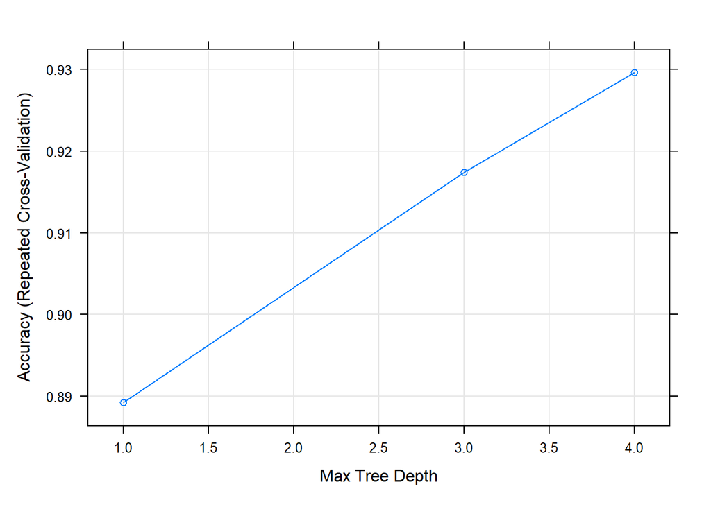

```r
plot(up_dt_clf)
```

Perform hyperparameter tuning using `tuneLength`.

```r
up_dt_clf <- train_model_clf("rpart2", train_set_clf_up, tuneLength = 10)
```

```
## note: only 7 possible values of the max tree depth from the initial fit.
##  Truncating the grid to 7 .
##
## CART
##
## 880 samples
##  32 predictor
##   2 classes: 'fail', 'pass'
##
## Pre-processing: centered (72), scaled (72)
## Resampling: Cross-Validated (10 fold, repeated 10 times)
## Summary of sample sizes: 792, 792, 792, 792, 792, 792, ...
## Resampling results across tuning parameters:
##
##   maxdepth  Accuracy   Kappa
##    1        0.8892045  0.7784091
##    3        0.9173864  0.8347727
##    4        0.9238636  0.8477273
##    7        0.9294318  0.8588636
##    8        0.9294318  0.8588636
##   11        0.9294318  0.8588636
##   12        0.9294318  0.8588636
##
## Accuracy was used to select the optimal model using the largest value.
## The final value used for the model was maxdepth = 7.
```

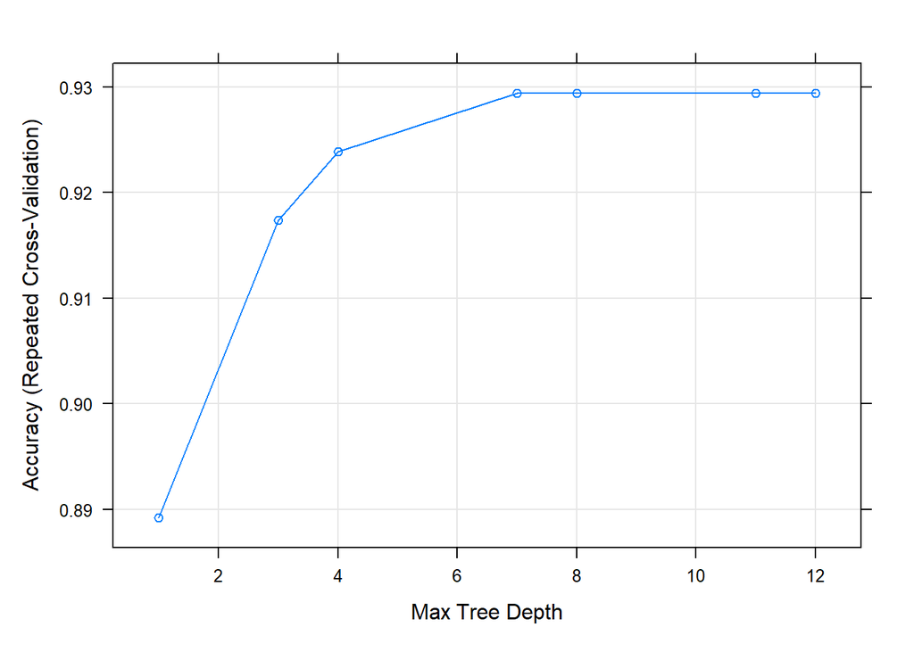

```r
plot(up_dt_clf)
```

Tuning done.

```r
up_dt_metrics_clf <- evaluate_model_clf(up_dt_clf, "Decision Tree")
```

```
## Confusion Matrix and Statistics
##
##           Reference
## Prediction fail pass
##       fail   16   11
##       pass    4   98
##
##                Accuracy : 0.8837
##                  95% CI : (0.8155, 0.9334)
##     No Information Rate : 0.845
##     P-Value [Acc > NIR] : 0.1352
##
##                   Kappa : 0.6117
##
##  Mcnemar's Test P-Value : 0.1213
##
##               Precision : 0.5926
##                  Recall : 0.8000
##                      F1 : 0.6809
##              Prevalence : 0.1550
##          Detection Rate : 0.1240
##    Detection Prevalence : 0.2093
##       Balanced Accuracy : 0.8495
##
##        'Positive' Class : fail
##
```

#### 2. Random Forest

- method = ‘ranger’
- Type: Regression, Classification
- Tuning parameters:
  - mtry (#Randomly Selected Predictors)
  - splitrule (Splitting Rule)
  - min.node.size (Minimal Node Size)
- Required packages: e1071, ranger, dplyr
- A model-specific variable importance metric is available.

##### Original Train Set

```r
rf_clf <- train_model_clf("ranger")
```

```
## Random Forest
##
## 520 samples
##  32 predictor
##   2 classes: 'fail', 'pass'
##
## Pre-processing: centered (72), scaled (72)
## Resampling: Cross-Validated (10 fold, repeated 10 times)
## Summary of sample sizes: 468, 468, 468, 468, 468, 468, ...
## Resampling results across tuning parameters:
##
##   mtry  splitrule   Accuracy   Kappa
##    2    gini        0.8744231  0.2633357
##    2    extratrees  0.8594231  0.1295123
##   37    gini        0.9307692  0.7051503
##   37    extratrees  0.9275000  0.6794896
##   72    gini        0.9313462  0.7069938
##   72    extratrees  0.9350000  0.7230234
##
## Tuning parameter 'min.node.size' was held constant at a value of 1
## Accuracy was used to select the optimal model using the largest value.
## The final values used for the model were mtry = 72, splitrule = extratrees
##  and min.node.size = 1.
```

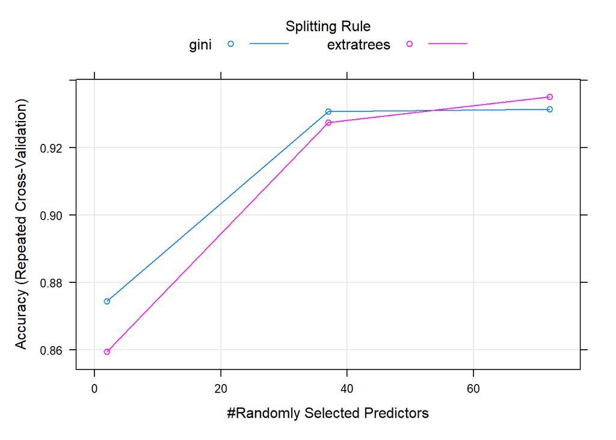

```r
plot(rf_clf)
```

Perform hyperparameter tuning using `tuneLength`.

```r
rf_clf <- train_model_clf("ranger", tuneLength = 7)
```

```
## Random Forest
##
## 520 samples
##  32 predictor
##   2 classes: 'fail', 'pass'
##
## Pre-processing: centered (72), scaled (72)
## Resampling: Cross-Validated (10 fold, repeated 10 times)
## Summary of sample sizes: 468, 468, 468, 468, 468, 468, ...
## Resampling results across tuning parameters:
##
##   mtry  splitrule   Accuracy   Kappa
##    2    gini        0.8753846  0.2723578
##    2    extratrees  0.8582692  0.1202263
##   13    gini        0.9336538  0.7118338
##   13    extratrees  0.9017308  0.5067021
##   25    gini        0.9311538  0.7082097
##   25    extratrees  0.9217308  0.6373321
##   37    gini        0.9313462  0.7085045
##   37    extratrees  0.9257692  0.6709289
##   48    gini        0.9296154  0.7010125
##   48    extratrees  0.9300000  0.6973189
##   60    gini        0.9315385  0.7095738
##   60    extratrees  0.9351923  0.7227439
##   72    gini        0.9311538  0.7077921
##   72    extratrees  0.9344231  0.7236122
##
## Tuning parameter 'min.node.size' was held constant at a value of 1
## Accuracy was used to select the optimal model using the largest value.
## The final values used for the model were mtry = 60, splitrule = extratrees
##  and min.node.size = 1.
```

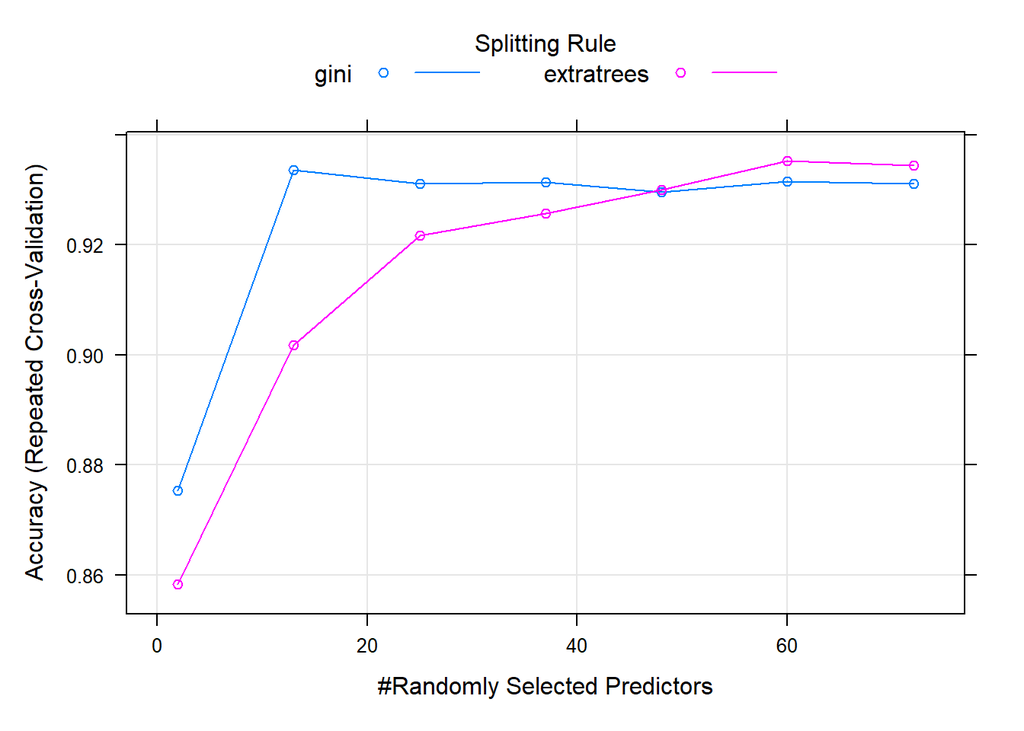

```r
plot(rf_clf)
```

Tuning done.

```r
rf_metrics_clf <- evaluate_model_clf(rf_clf, "Random Forest")
```

```
## Confusion Matrix and Statistics
##
##           Reference
## Prediction fail pass
##       fail   14    4
##       pass    6  105
##
##                Accuracy : 0.9225
##                  95% CI : (0.8621, 0.9622)
##     No Information Rate : 0.845
##     P-Value [Acc > NIR] : 0.006716
##
##                   Kappa : 0.6915
##
##  Mcnemar's Test P-Value : 0.751830
##
##               Precision : 0.7778
##                  Recall : 0.7000
##                      F1 : 0.7368
##              Prevalence : 0.1550
##          Detection Rate : 0.1085
##    Detection Prevalence : 0.1395
##       Balanced Accuracy : 0.8317
##
##        'Positive' Class : fail
##
```

##### Down-Sampled Train Set

```r
down_rf_clf <- train_model_clf("ranger", train_set_clf_down)
```

```
## Random Forest
##
## 160 samples
##  32 predictor
##   2 classes: 'fail', 'pass'
##
## Pre-processing: centered (72), scaled (72)
## Resampling: Cross-Validated (10 fold, repeated 10 times)
## Summary of sample sizes: 144, 144, 144, 144, 144, 144, ...
## Resampling results across tuning parameters:
##
##   mtry  splitrule   Accuracy  Kappa
##    2    gini        0.795625  0.59125
##    2    extratrees  0.757500  0.51500
##   37    gini        0.879375  0.75875
##   37    extratrees  0.846875  0.69375
##   72    gini        0.880000  0.76000
##   72    extratrees  0.868125  0.73625
##
## Tuning parameter 'min.node.size' was held constant at a value of 1
## Accuracy was used to select the optimal model using the largest value.
## The final values used for the model were mtry = 72, splitrule = gini
##  and min.node.size = 1.
```

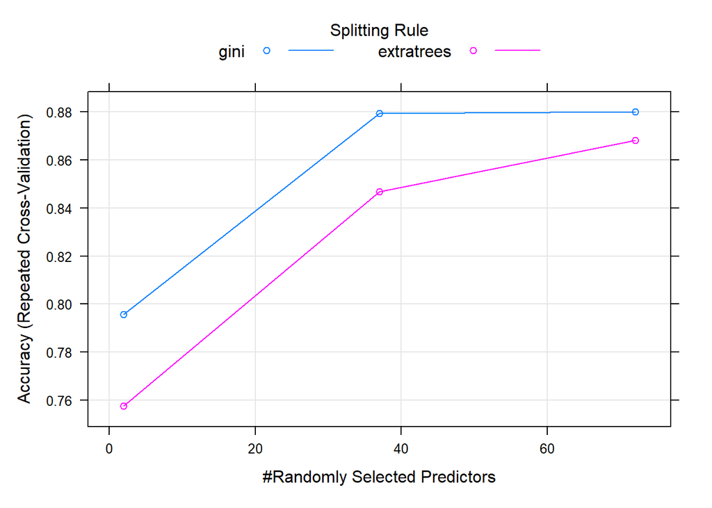

```r
plot(down_rf_clf)
```

Perform hyperparameter tuning using `tuneLength`.

```r
down_rf_clf <- train_model_clf("ranger", train_set_clf_down, tuneLength = 7)
```

```
## Random Forest
##
## 160 samples
##  32 predictor
##   2 classes: 'fail', 'pass'
##
## Pre-processing: centered (72), scaled (72)
## Resampling: Cross-Validated (10 fold, repeated 10 times)
## Summary of sample sizes: 144, 144, 144, 144, 144, 144, ...
## Resampling results across tuning parameters:
##
##   mtry  splitrule   Accuracy  Kappa
##    2    gini        0.801875  0.60375
##    2    extratrees  0.746875  0.49375
##   13    gini        0.876250  0.75250
##   13    extratrees  0.814375  0.62875
##   25    gini        0.891250  0.78250
##   25    extratrees  0.843750  0.68750
##   37    gini        0.886250  0.77250
##   37    extratrees  0.853750  0.70750
##   48    gini        0.880000  0.76000
##   48    extratrees  0.854375  0.70875
##   60    gini        0.881875  0.76375
##   60    extratrees  0.869375  0.73875
##   72    gini        0.879375  0.75875
##   72    extratrees  0.873125  0.74625
##
## Tuning parameter 'min.node.size' was held constant at a value of 1
## Accuracy was used to select the optimal model using the largest value.
## The final values used for the model were mtry = 25, splitrule = gini
##  and min.node.size = 1.
```

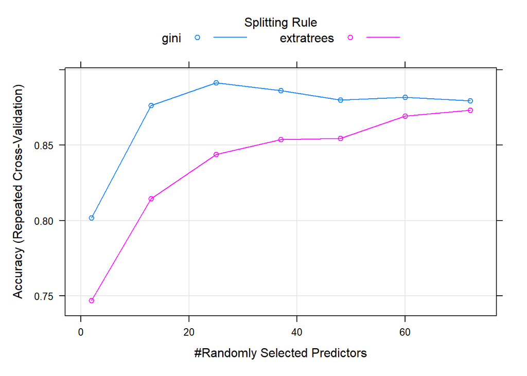

```r
plot(down_rf_clf)
```

Tuning done.

```r
down_rf_metrics_clf <- evaluate_model_clf(down_rf_clf, "Random Forest")
```

```
## Confusion Matrix and Statistics
##
##           Reference
## Prediction fail pass
##       fail   17   13
##       pass    3   96
##
##                Accuracy : 0.876
##                  95% CI : (0.8064, 0.9274)
##     No Information Rate : 0.845
##     P-Value [Acc > NIR] : 0.19935
##
##                   Kappa : 0.6069
##
##  Mcnemar's Test P-Value : 0.02445
##
##               Precision : 0.5667
##                  Recall : 0.8500
##                      F1 : 0.6800
##              Prevalence : 0.1550
##          Detection Rate : 0.1318
##    Detection Prevalence : 0.2326
##       Balanced Accuracy : 0.8654
##
##        'Positive' Class : fail
##
```

##### Up-Sampled Train Set

```r
up_rf_clf <- train_model_clf("ranger", train_set_clf_up)
```

```
## Random Forest
##
## 880 samples
##  32 predictor
##   2 classes: 'fail', 'pass'
##
## Pre-processing: centered (72), scaled (72)
## Resampling: Cross-Validated (10 fold, repeated 10 times)
## Summary of sample sizes: 792, 792, 792, 792, 792, 792, ...
## Resampling results across tuning parameters:
##
##   mtry  splitrule   Accuracy   Kappa
##    2    gini        0.9803409  0.9606818
##    2    extratrees  0.9795455  0.9590909
##   37    gini        0.9789773  0.9579545
##   37    extratrees  0.9820455  0.9640909
##   72    gini        0.9786364  0.9572727
##   72    extratrees  0.9786364  0.9572727
##
## Tuning parameter 'min.node.size' was held constant at a value of 1
## Accuracy was used to select the optimal model using the largest value.
## The final values used for the model were mtry = 37, splitrule = extratrees
##  and min.node.size = 1.
```

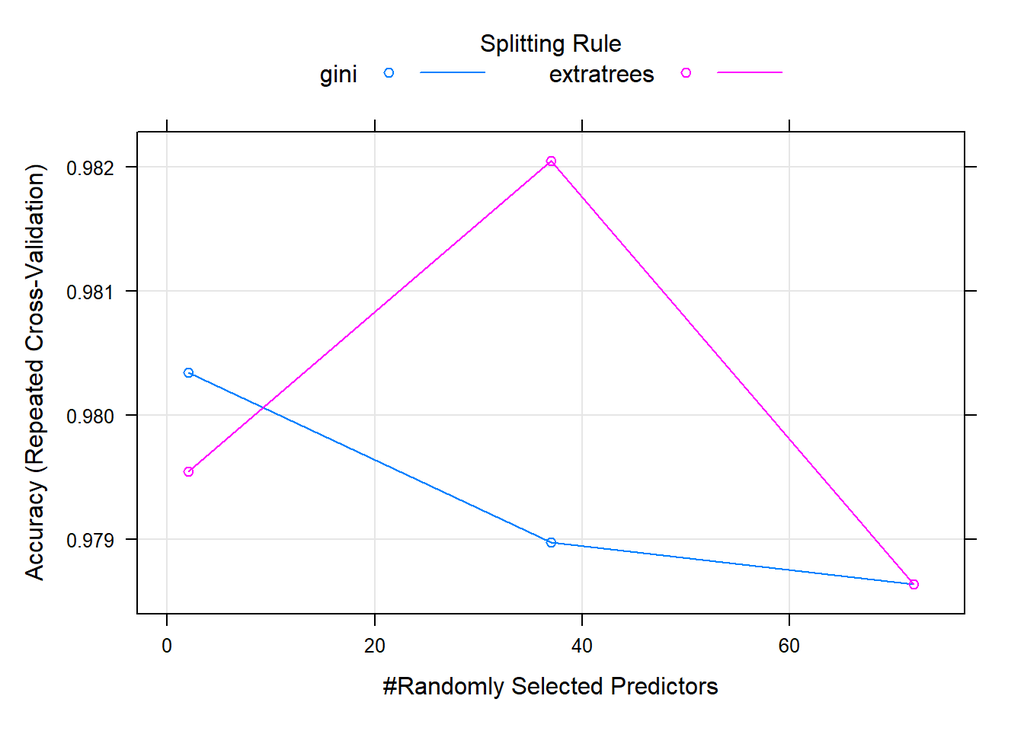

```r
plot(up_rf_clf)
```

Perform hyperparameter tuning using `tuneLength`.

```r
up_rf_clf <- train_model_clf("ranger", train_set_clf_up, tuneLength = 7)
```

```
## Random Forest
##
## 880 samples
##  32 predictor
##   2 classes: 'fail', 'pass'
##
## Pre-processing: centered (72), scaled (72)
## Resampling: Cross-Validated (10 fold, repeated 10 times)
## Summary of sample sizes: 792, 792, 792, 792, 792, 792, ...
## Resampling results across tuning parameters:
##
##   mtry  splitrule   Accuracy   Kappa
##    2    gini        0.9812500  0.9625000
##    2    extratrees  0.9801136  0.9602273
##   13    gini        0.9807955  0.9615909
##   13    extratrees  0.9819318  0.9638636
##   25    gini        0.9794318  0.9588636
##   25    extratrees  0.9802273  0.9604545
##   37    gini        0.9785227  0.9570455
##   37    extratrees  0.9815909  0.9631818
##   48    gini        0.9786364  0.9572727
##   48    extratrees  0.9817045  0.9634091
##   60    gini        0.9787500  0.9575000
##   60    extratrees  0.9803409  0.9606818
##   72    gini        0.9781818  0.9563636
##   72    extratrees  0.9780682  0.9561364
##
## Tuning parameter 'min.node.size' was held constant at a value of 1
## Accuracy was used to select the optimal model using the largest value.
## The final values used for the model were mtry = 13, splitrule = extratrees
##  and min.node.size = 1.
```

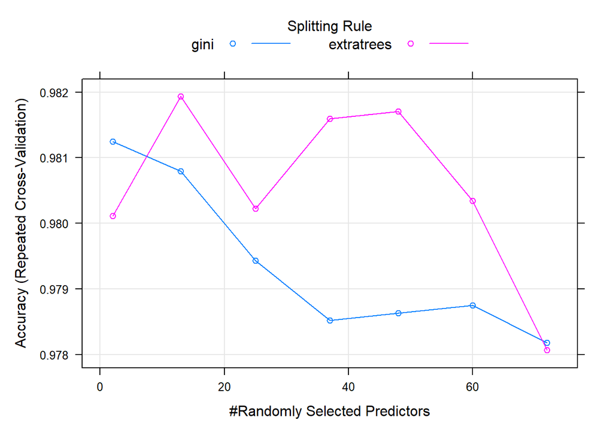

```r
plot(up_rf_clf)
```

Tuning done.

```r
up_rf_metrics_clf <- evaluate_model_clf(up_rf_clf, "Random Forest")
```

```
## Confusion Matrix and Statistics
##
##           Reference
## Prediction fail pass
##       fail   12    3
##       pass    8  106
##
##                Accuracy : 0.9147
##                  95% CI : (0.8525, 0.9567)
##     No Information Rate : 0.845
##     P-Value [Acc > NIR] : 0.01442
##
##                   Kappa : 0.6375
##
##  Mcnemar's Test P-Value : 0.22780
##
##               Precision : 0.80000
##                  Recall : 0.60000
##                      F1 : 0.68571
##              Prevalence : 0.15504
##          Detection Rate : 0.09302
##    Detection Prevalence : 0.11628
##       Balanced Accuracy : 0.78624
##
##        'Positive' Class : fail
##
```

#### 3. SVM with Polynomial Kernel

- method = ‘svmPoly’
- Type: Regression, Classification
- Tuning parameters:
  - degree (Polynomial Degree)
  - scale (Scale)
  - C (Cost)
- Required packages: kernlab

##### Original Train Set

```r
svm_poly_clf <- train_model_clf("svmPoly")
```

```
## Support Vector Machines with Polynomial Kernel
##
## 520 samples
##  32 predictor
##   2 classes: 'fail', 'pass'
##
## Pre-processing: centered (72), scaled (72)
## Resampling: Cross-Validated (10 fold, repeated 10 times)
## Summary of sample sizes: 468, 468, 468, 468, 468, 468, ...
## Resampling results across tuning parameters:
##
##   degree  scale  C     Accuracy   Kappa
##   1       0.001  0.25  0.8461538  0.000000000
##   1       0.001  0.50  0.8461538  0.000000000
##   1       0.001  1.00  0.8461538  0.000000000
```

[output cut: 27 more lines]

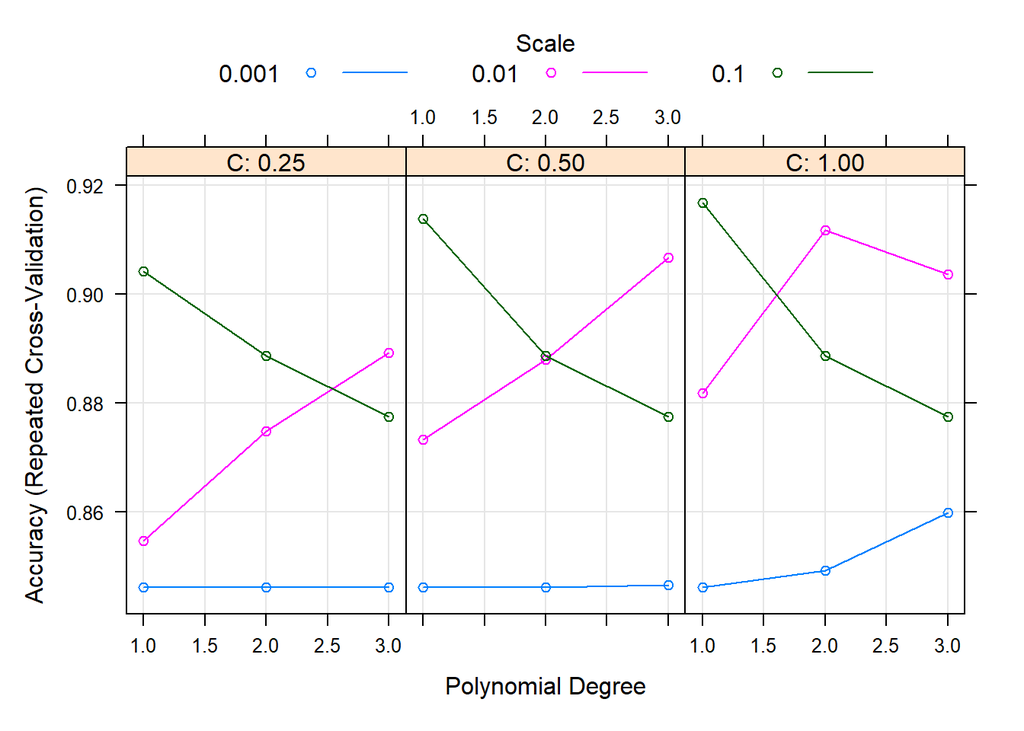

```r
plot(svm_poly_clf)
```

Perform hyperparameter tuning using `tuneGrid`.

```r
svm_poly_tuneGrid_clf <- expand.grid(
  degree = 1,
  scale = c(0.01, 0.1),
  C = seq(0.1, 1.5, 0.05)
)

svm_poly_clf <- train_model_clf("svmPoly", tuneGrid = svm_poly_tuneGrid_clf)
```

```
## Support Vector Machines with Polynomial Kernel
##
## 520 samples
##  32 predictor
##   2 classes: 'fail', 'pass'
##
## Pre-processing: centered (72), scaled (72)
## Resampling: Cross-Validated (10 fold, repeated 10 times)
## Summary of sample sizes: 468, 468, 468, 468, 468, 468, ...
## Resampling results across tuning parameters:
##
##   scale  C     Accuracy   Kappa
##   0.01   0.10  0.8461538  0.00000000
##   0.01   0.15  0.8461538  0.00000000
##   0.01   0.20  0.8492308  0.03086319
##   0.01   0.25  0.8546154  0.08394023
##   0.01   0.30  0.8576923  0.11365443
##   0.01   0.35  0.8638462  0.17052312
##   0.01   0.40  0.8682692  0.21034175
##   0.01   0.45  0.8713462  0.24060396
##   0.01   0.50  0.8732692  0.26059984
##   0.01   0.55  0.8755769  0.28188147
##   0.01   0.60  0.8753846  0.28132437
##   0.01   0.65  0.8773077  0.29947793
##   0.01   0.70  0.8782692  0.31299249
##   0.01   0.75  0.8803846  0.33723638
##   0.01   0.80  0.8819231  0.35690555
##   0.01   0.85  0.8821154  0.36999562
##   0.01   0.90  0.8826923  0.38047267
##   0.01   0.95  0.8825000  0.39115441
##   0.01   1.00  0.8817308  0.39497286
##   0.01   1.05  0.8821154  0.40146122
##   0.01   1.10  0.8838462  0.41961460
##   0.01   1.15  0.8842308  0.42965830
##   0.01   1.20  0.8853846  0.43706948
##   0.01   1.25  0.8878846  0.45460578
##   0.01   1.30  0.8900000  0.47114159
##   0.01   1.35  0.8917308  0.48367835
##   0.01   1.40  0.8919231  0.48581998
##   0.01   1.45  0.8938462  0.50044125
```

[output cut: 19 more lines]

```
##   0.10   1.00  0.9167308  0.66053735
##   0.10   1.05  0.9163462  0.65870244
##   0.10   1.10  0.9155769  0.65680728
##   0.10   1.15  0.9161538  0.65811114
##   0.10   1.20  0.9163462  0.65900978
##   0.10   1.25  0.9167308  0.66071945
##   0.10   1.30  0.9161538  0.65865021
##   0.10   1.35  0.9155769  0.65711508
##   0.10   1.40  0.9148077  0.65527095
##   0.10   1.45  0.9140385  0.65206420
##   0.10   1.50  0.9140385  0.65320292
##
## Tuning parameter 'degree' was held constant at a value of 1
## Accuracy was used to select the optimal model using the largest value.
## The final values used for the model were degree = 1, scale = 0.1 and C = 0.7.
```

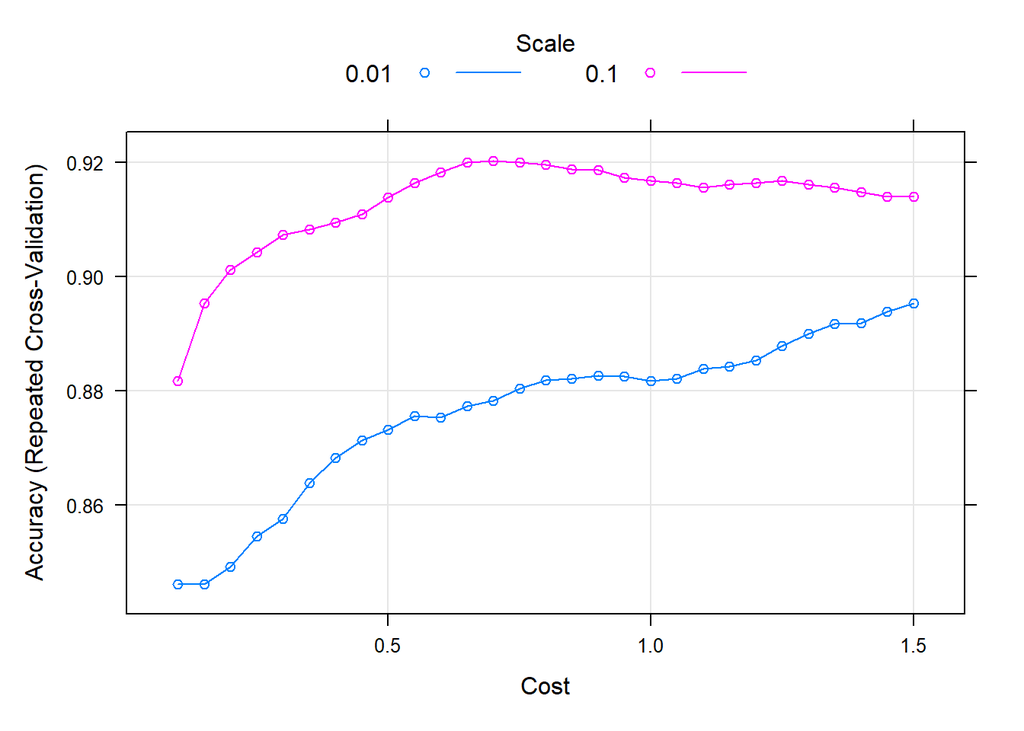

```r
plot(svm_poly_clf)
```

Tuning done.

```r
svm_poly_metrics_clf <- evaluate_model_clf(svm_poly_clf, "Support Vector Machine")
```

```
## Confusion Matrix and Statistics
##
##           Reference
## Prediction fail pass
##       fail   14    5
##       pass    6  104
##
##                Accuracy : 0.9147
##                  95% CI : (0.8525, 0.9567)
##     No Information Rate : 0.845
##     P-Value [Acc > NIR] : 0.01442
##
##                   Kappa : 0.6678
##
##  Mcnemar's Test P-Value : 1.00000
##
##               Precision : 0.7368
##                  Recall : 0.7000
##                      F1 : 0.7179
##              Prevalence : 0.1550
##          Detection Rate : 0.1085
##    Detection Prevalence : 0.1473
##       Balanced Accuracy : 0.8271
##
##        'Positive' Class : fail
##
```

##### Down-Sampled Train Set

```r
down_svm_poly_clf <- train_model_clf("svmPoly", train_set_clf_down)
```

```
## Support Vector Machines with Polynomial Kernel
##
## 160 samples
##  32 predictor
##   2 classes: 'fail', 'pass'
##
## Pre-processing: centered (72), scaled (72)
## Resampling: Cross-Validated (10 fold, repeated 10 times)
## Summary of sample sizes: 144, 144, 144, 144, 144, 144, ...
## Resampling results across tuning parameters:
##
##   degree  scale  C     Accuracy  Kappa
##   1       0.001  0.25  0.768750  0.53750
##   1       0.001  0.50  0.768750  0.53750
##   1       0.001  1.00  0.770000  0.54000
```

[output cut: 27 more lines]

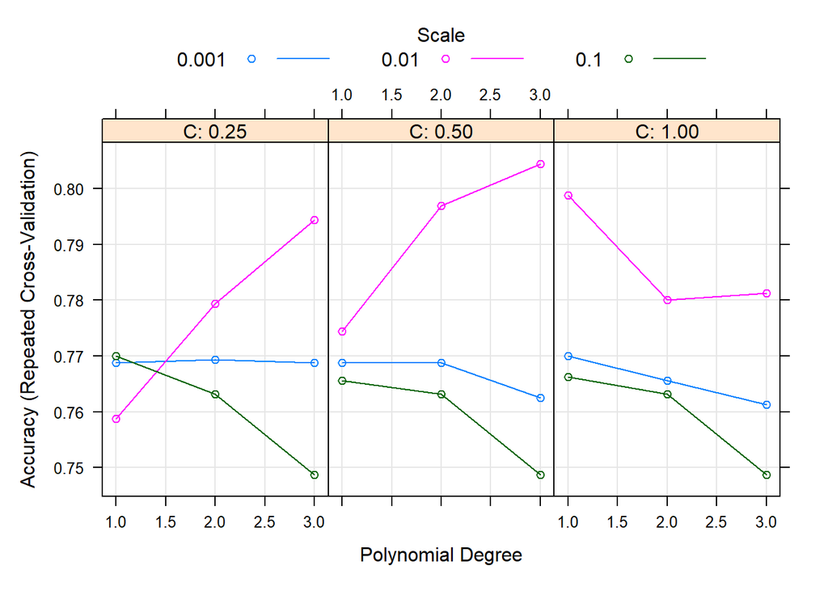

```r
plot(down_svm_poly_clf)
```

Perform hyperparameter tuning using `tuneGrid`.

```r
down_svm_poly_tuneGrid_clf <- expand.grid(
  degree = 3,
  scale = 0.01,
  C = seq(0.25, 1, 0.05)
)

down_svm_poly_clf <- train_model_clf(
  "svmPoly",
  train_set_clf_down,
  tuneGrid = down_svm_poly_tuneGrid_clf
)
```

```
## Support Vector Machines with Polynomial Kernel
##
## 160 samples
##  32 predictor
##   2 classes: 'fail', 'pass'
##
## Pre-processing: centered (72), scaled (72)
## Resampling: Cross-Validated (10 fold, repeated 10 times)
## Summary of sample sizes: 144, 144, 144, 144, 144, 144, ...
## Resampling results across tuning parameters:
##
##   C     Accuracy  Kappa
##   0.25  0.794375  0.58875
##   0.30  0.800000  0.60000
##   0.35  0.801875  0.60375
##   0.40  0.800625  0.60125
##   0.45  0.802500  0.60500
##   0.50  0.804375  0.60875
##   0.55  0.801875  0.60375
##   0.60  0.793125  0.58625
##   0.65  0.795000  0.59000
##   0.70  0.790625  0.58125
##   0.75  0.788750  0.57750
##   0.80  0.785000  0.57000
##   0.85  0.784375  0.56875
##   0.90  0.784375  0.56875
##   0.95  0.781250  0.56250
##   1.00  0.781250  0.56250
##
## Tuning parameter 'degree' was held constant at a value of 3
## Tuning
##  parameter 'scale' was held constant at a value of 0.01
## Accuracy was used to select the optimal model using the largest value.
## The final values used for the model were degree = 3, scale = 0.01 and C = 0.5.
```

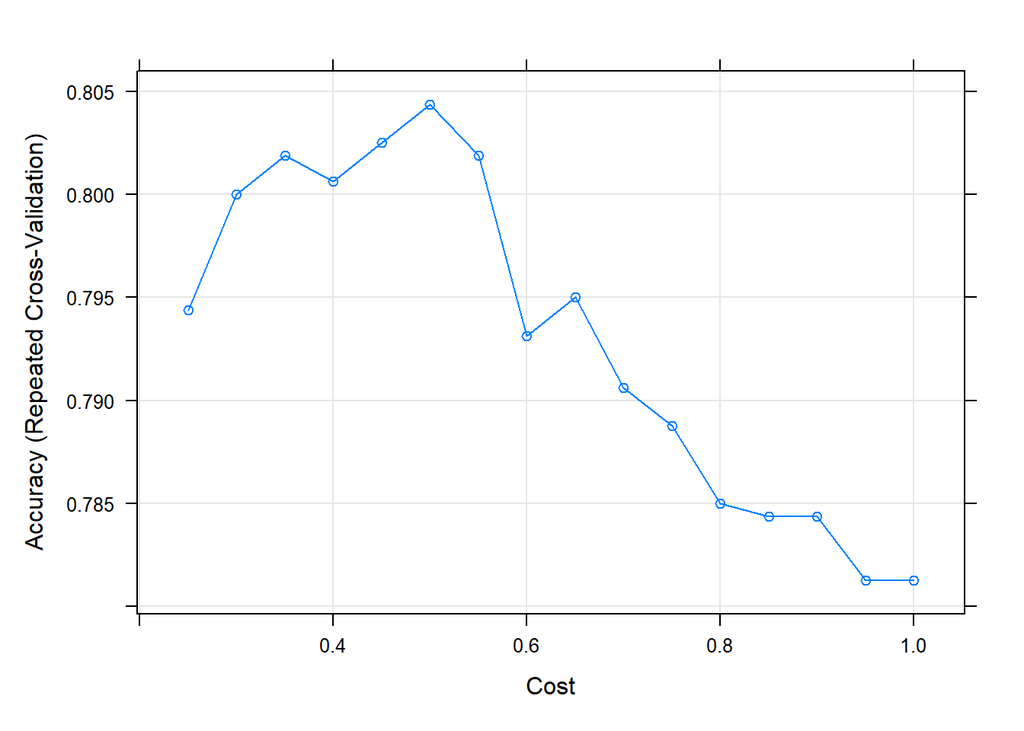

```r
plot(down_svm_poly_clf)
```

Tuning done.

```r
down_svm_poly_metrics_clf <- evaluate_model_clf(down_svm_poly_clf, "Support Vector Machine")
```

```
## Confusion Matrix and Statistics
##
##           Reference
## Prediction fail pass
##       fail   18   16
##       pass    2   93
##
##                Accuracy : 0.8605
##                  95% CI : (0.7885, 0.9152)
##     No Information Rate : 0.845
##     P-Value [Acc > NIR] : 0.366920
##
##                   Kappa : 0.5858
##
##  Mcnemar's Test P-Value : 0.002183
##
##               Precision : 0.5294
##                  Recall : 0.9000
##                      F1 : 0.6667
##              Prevalence : 0.1550
##          Detection Rate : 0.1395
##    Detection Prevalence : 0.2636
##       Balanced Accuracy : 0.8766
##
##        'Positive' Class : fail
##
```

##### Up-Sampled Train Set

```r
up_svm_poly_clf <- train_model_clf("svmPoly", train_set_clf_up)
```

```
## Support Vector Machines with Polynomial Kernel
##
## 880 samples
##  32 predictor
##   2 classes: 'fail', 'pass'
##
## Pre-processing: centered (72), scaled (72)
## Resampling: Cross-Validated (10 fold, repeated 10 times)
## Summary of sample sizes: 792, 792, 792, 792, 792, 792, ...
## Resampling results across tuning parameters:
##
##   degree  scale  C     Accuracy   Kappa
##   1       0.001  0.25  0.8207955  0.6415909
##   1       0.001  0.50  0.8480682  0.6961364
##   1       0.001  1.00  0.8709091  0.7418182
```

[output cut: 27 more lines]

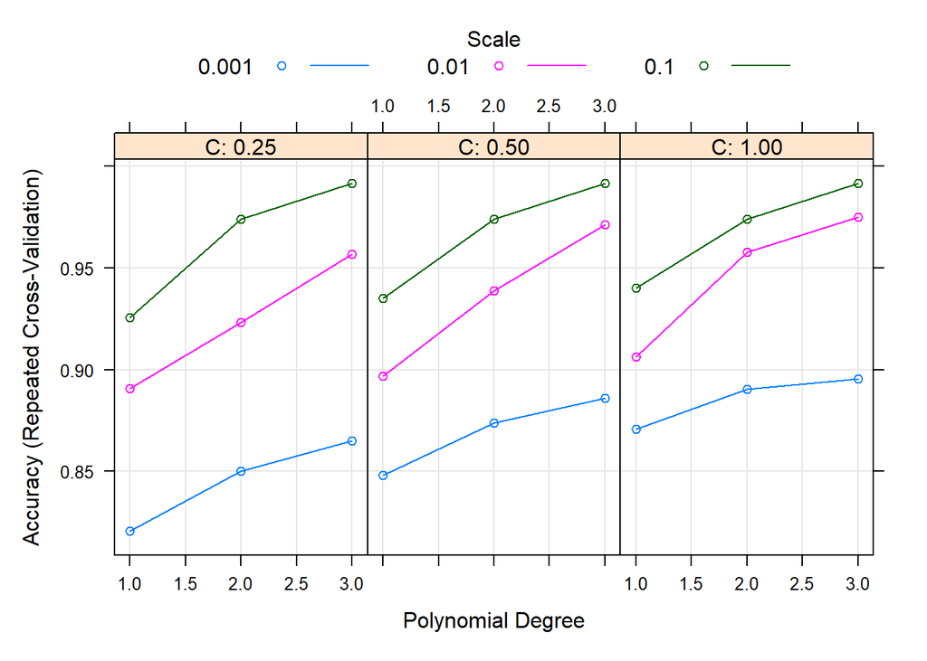

```r
plot(up_svm_poly_clf)
```

Perform hyperparameter tuning using `tuneGrid`.

```r
up_svm_poly_tuneGrid_clf <- expand.grid(
  degree = 3,
  scale = 0.1,
  C = seq(0.05, 0.25, 0.05)
)

up_svm_poly_clf <- train_model_clf(
  "svmPoly",
  train_set_clf_up,
  tuneGrid = up_svm_poly_tuneGrid_clf
)
```

```
## Support Vector Machines with Polynomial Kernel
##
## 880 samples
##  32 predictor
##   2 classes: 'fail', 'pass'
##
## Pre-processing: centered (72), scaled (72)
## Resampling: Cross-Validated (10 fold, repeated 10 times)
## Summary of sample sizes: 792, 792, 792, 792, 792, 792, ...
## Resampling results across tuning parameters:
##
##   C     Accuracy   Kappa
##   0.05  0.9913636  0.9827273
##   0.10  0.9913636  0.9827273
##   0.15  0.9913636  0.9827273
##   0.20  0.9913636  0.9827273
##   0.25  0.9913636  0.9827273
##
## Tuning parameter 'degree' was held constant at a value of 3
## Tuning
##  parameter 'scale' was held constant at a value of 0.1
## Accuracy was used to select the optimal model using the largest value.
## The final values used for the model were degree = 3, scale = 0.1 and C = 0.05.
```

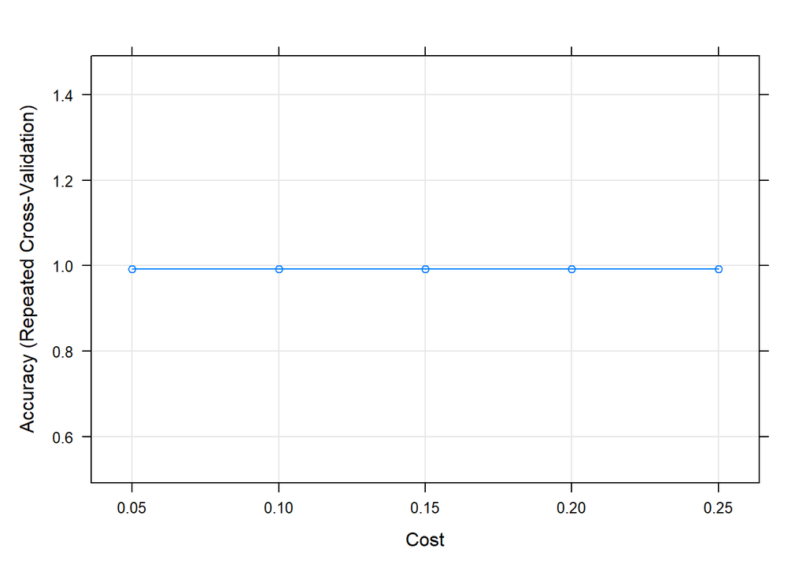

```r
plot(up_svm_poly_clf)
```

Tuning done.

```r
up_svm_poly_metrics_clf <- evaluate_model_clf(up_svm_poly_clf, "Support Vector Machine")
```

```
## Confusion Matrix and Statistics
##
##           Reference
## Prediction fail pass
##       fail    7    1
##       pass   13  108
##
##                Accuracy : 0.8915
##                  95% CI : (0.8246, 0.9394)
##     No Information Rate : 0.845
##     P-Value [Acc > NIR] : 0.086135
##
##                   Kappa : 0.4514
##
##  Mcnemar's Test P-Value : 0.003283
##
##               Precision : 0.87500
##                  Recall : 0.35000
##                      F1 : 0.50000
##              Prevalence : 0.15504
##          Detection Rate : 0.05426
##    Detection Prevalence : 0.06202
##       Balanced Accuracy : 0.67041
##
##        'Positive' Class : fail
##
```

#### 4. K-Nearest Neighbors

- method = ‘knn’
- Type: Classification, Regression
- Tuning parameters:
  - k (#Neighbors)

##### Original Train Set

```r
knn_clf <- train_model_clf("knn")
```

```
## k-Nearest Neighbors
##
## 520 samples
##  32 predictor
##   2 classes: 'fail', 'pass'
##
## Pre-processing: centered (72), scaled (72)
## Resampling: Cross-Validated (10 fold, repeated 10 times)
## Summary of sample sizes: 468, 468, 468, 468, 468, 468, ...
## Resampling results across tuning parameters:
##
##   k  Accuracy   Kappa
##   5  0.8580769  0.2849825
##   7  0.8525000  0.2177127
##   9  0.8575000  0.2242462
##
## Accuracy was used to select the optimal model using the largest value.
## The final value used for the model was k = 5.
```

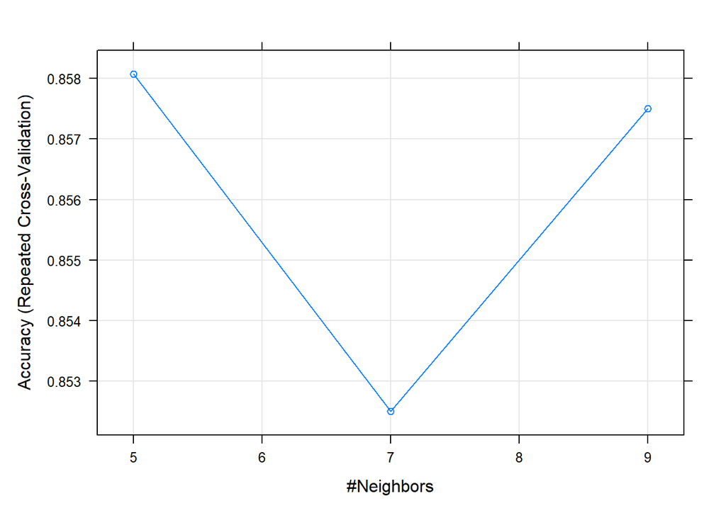

```r
plot(knn_clf)
```

Perform hyperparameter tuning using `tuneGrid`.

```r
knn_clf <- train_model_clf("knn", tuneGrid = expand.grid(k = c(3, 5, 7, 11)))
```

```
## k-Nearest Neighbors
##
## 520 samples
##  32 predictor
##   2 classes: 'fail', 'pass'
##
## Pre-processing: centered (72), scaled (72)
## Resampling: Cross-Validated (10 fold, repeated 10 times)
## Summary of sample sizes: 468, 468, 468, 468, 468, 468, ...
## Resampling results across tuning parameters:
##
##   k   Accuracy   Kappa
##    3  0.8526923  0.3232641
##    5  0.8580769  0.2849825
##    7  0.8525000  0.2177127
##   11  0.8551923  0.1845602
##
## Accuracy was used to select the optimal model using the largest value.
## The final value used for the model was k = 5.
```

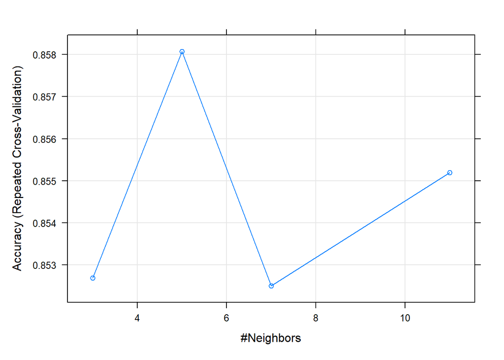

```r
plot(knn_clf)
```

No further tuning necessary.

```r
knn_metrics_clf <- evaluate_model_clf(knn_clf, "K-Nearest Neighbors")
```

```
## Confusion Matrix and Statistics
##
##           Reference
## Prediction fail pass
##       fail    8    5
##       pass   12  104
##
##                Accuracy : 0.8682
##                  95% CI : (0.7974, 0.9213)
##     No Information Rate : 0.845
##     P-Value [Acc > NIR] : 0.2776
##
##                   Kappa : 0.4132
##
##  Mcnemar's Test P-Value : 0.1456
##
##               Precision : 0.61538
##                  Recall : 0.40000
##                      F1 : 0.48485
##              Prevalence : 0.15504
##          Detection Rate : 0.06202
##    Detection Prevalence : 0.10078
##       Balanced Accuracy : 0.67706
##
##        'Positive' Class : fail
##
```